# Entrega 1. Modelos de regresión lineal

Pablo Daniel Barillas Moreno, Carné No. 22193

Mathew Cordero Aquino, Carné No. 22982

2025-02-02

### Enlace al Repositorio del proyecto 2 de minería de datos del Grupo #1

[Repositorio en GitHub](https://github.com/DanielBarillas/Proyecto-2_MineriaDeDatos_Grupo-1.git)

### 1. Descargue los conjuntos de datos.

Para este punto, ya se ha realizado el proceso para descargar del sitio web: [House Prices - Advanced Regression Techniques](https://kaggle.com/competitions/house-prices-advanced-regression-techniques), la data de entrenamiento y la data de prueba, ambos extraídos desde la carpeta “house_prices_data/” en data frames llamados train_data (data de entrenamiento) y test_data (data de prueba), sin convertir automáticamente las variables categóricas en factores (stringsAsFactors = FALSE). Luego, se realiza una inspección inicial de train_data mediante tres funciones: head(train_data), que muestra las primeras filas del dataset; str(train_data), que despliega la estructura del data frame, incluyendo el tipo de cada variable; y summary(train_data), que proporciona un resumen estadístico de las variables numéricas y una descripción general de las categóricas.

```r
train_data <- read.csv("house_prices_data/train.csv", stringsAsFactors = FALSE)
test_data <- read.csv("house_prices_data/test.csv", stringsAsFactors = FALSE)

head(train_data)   # Muestra las primeras filas
```

```
##   Id MSSubClass MSZoning LotFrontage LotArea Street Alley LotShape LandContour
## 1  1         60       RL          65    8450   Pave  <NA>      Reg         Lvl
## 2  2         20       RL          80    9600   Pave  <NA>      Reg         Lvl
## 3  3         60       RL          68   11250   Pave  <NA>      IR1         Lvl
## 4  4         70       RL          60    9550   Pave  <NA>      IR1         Lvl
## 5  5         60       RL          84   14260   Pave  <NA>      IR1         Lvl
## 6  6         50       RL          85   14115   Pave  <NA>      IR1         Lvl
##   Utilities LotConfig LandSlope Neighborhood Condition1 Condition2 BldgType
## 1    AllPub    Inside       Gtl      CollgCr       Norm       Norm     1Fam
## 2    AllPub       FR2       Gtl      Veenker      Feedr       Norm     1Fam
## 3    AllPub    Inside       Gtl      CollgCr       Norm       Norm     1Fam
## 4    AllPub    Corner       Gtl      Crawfor       Norm       Norm     1Fam
## 5    AllPub       FR2       Gtl      NoRidge       Norm       Norm     1Fam
## 6    AllPub    Inside       Gtl      Mitchel       Norm       Norm     1Fam
##   HouseStyle OverallQual OverallCond YearBuilt YearRemodAdd RoofStyle RoofMatl
```

[output cut: 69 more lines]

```r
str(train_data)    # Muestra la estructura del dataset
```

```
## 'data.frame':    1460 obs. of  81 variables:
##  $ Id           : int  1 2 3 4 5 6 7 8 9 10 ...
##  $ MSSubClass   : int  60 20 60 70 60 50 20 60 50 190 ...
##  $ MSZoning     : chr  "RL" "RL" "RL" "RL" ...
##  $ LotFrontage  : int  65 80 68 60 84 85 75 NA 51 50 ...
##  $ LotArea      : int  8450 9600 11250 9550 14260 14115 10084 10382 6120 7420 ...
##  $ Street       : chr  "Pave" "Pave" "Pave" "Pave" ...
##  $ Alley        : chr  NA NA NA NA ...
##  $ LotShape     : chr  "Reg" "Reg" "IR1" "IR1" ...
##  $ LandContour  : chr  "Lvl" "Lvl" "Lvl" "Lvl" ...
##  $ Utilities    : chr  "AllPub" "AllPub" "AllPub" "AllPub" ...
##  $ LotConfig    : chr  "Inside" "FR2" "Inside" "Corner" ...
##  $ LandSlope    : chr  "Gtl" "Gtl" "Gtl" "Gtl" ...
##  $ Neighborhood : chr  "CollgCr" "Veenker" "CollgCr" "Crawfor" ...
##  $ Condition1   : chr  "Norm" "Feedr" "Norm" "Norm" ...
```

[output cut: 67 more lines]

```r
summary(train_data) # Resumen estadístico
```

```
##        Id           MSSubClass      MSZoning          LotFrontage
##  Min.   :   1.0   Min.   : 20.0   Length:1460        Min.   : 21.00
##  1st Qu.: 365.8   1st Qu.: 20.0   Class :character   1st Qu.: 59.00
##  Median : 730.5   Median : 50.0   Mode  :character   Median : 69.00
##  Mean   : 730.5   Mean   : 56.9                      Mean   : 70.05
##  3rd Qu.:1095.2   3rd Qu.: 70.0                      3rd Qu.: 80.00
##  Max.   :1460.0   Max.   :190.0                      Max.   :313.00
##                                                      NA's   :259
##     LotArea          Street             Alley             LotShape
##  Min.   :  1300   Length:1460        Length:1460        Length:1460
##  1st Qu.:  7554   Class :character   Class :character   Class :character
##  Median :  9478   Mode  :character   Mode  :character   Mode  :character
##  Mean   : 10517
##  3rd Qu.: 11602
##  Max.   :215245
##
##  LandContour         Utilities          LotConfig          LandSlope
##  Length:1460        Length:1460        Length:1460        Length:1460
##  Class :character   Class :character   Class :character   Class :character
##  Mode  :character   Mode  :character   Mode  :character   Mode  :character
##
##
##
##
##  Neighborhood        Condition1         Condition2          BldgType
##  Length:1460        Length:1460        Length:1460        Length:1460
##  Class :character   Class :character   Class :character   Class :character
##  Mode  :character   Mode  :character   Mode  :character   Mode  :character
##
##
##
##
##   HouseStyle         OverallQual      OverallCond      YearBuilt
##  Length:1460        Min.   : 1.000   Min.   :1.000   Min.   :1872
##  Class :character   1st Qu.: 5.000   1st Qu.:5.000   1st Qu.:1954
##  Mode  :character   Median : 6.000   Median :5.000   Median :1973
##                     Mean   : 6.099   Mean   :5.575   Mean   :1971
##                     3rd Qu.: 7.000   3rd Qu.:6.000   3rd Qu.:2000
##                     Max.   :10.000   Max.   :9.000   Max.   :2010
##
```

[output cut: 113 more lines]

```
##  Min.   : 1.000   Min.   :2006   Length:1460        Length:1460
##  1st Qu.: 5.000   1st Qu.:2007   Class :character   Class :character
##  Median : 6.000   Median :2008   Mode  :character   Mode  :character
##  Mean   : 6.322   Mean   :2008
##  3rd Qu.: 8.000   3rd Qu.:2009
##  Max.   :12.000   Max.   :2010
##
##    SalePrice
##  Min.   : 34900
##  1st Qu.:129975
##  Median :163000
##  Mean   :180921
##  3rd Qu.:214000
##  Max.   :755000
##
```

### 2. Haga un análisis exploratorio extenso de los datos. Explique bien todos los hallazgos. No ponga solo gráficas y código. Debe llegar a conclusiones interesantes para poder predecir. Explique el preprocesamiento que necesitó hacer.

Análisis Exploratorio de Datos (EDA)

El objetivo de este análisis es entender la estructura de los datos, identificar patrones, detectar valores atípicos y preparar el dataset para su uso en modelos de regresión. Vamos a explorar el conjunto de datos train.csv.

El análisis exploratorio de datos (EDA) es fundamental para entender las características del dataset, identificar patrones y decidir qué variables serán útiles para la predicción del precio de las viviendas.

2.1. Cargar y Revisar los Datos…

Primero cargamos los datos y cargamos las librerías necesarias y revisamos su estructura.

```r
# Cargar librerías
library(tidyverse)
library(corrplot)
library(VIM)        # Para analizar valores faltantes
library(ggplot2)
library(dplyr)
library(caret)      # Para dividir los datos en entrenamiento y prueba

# Cargar los datos
train <- read_csv("house_prices_data/train.csv")
test <- read_csv("house_prices_data/test.csv")

# Ver la estructura de los datos
str(train)
```

```
## spc_tbl_ [1,460 × 81] (S3: spec_tbl_df/tbl_df/tbl/data.frame)
##  $ Id           : num [1:1460] 1 2 3 4 5 6 7 8 9 10 ...
##  $ MSSubClass   : num [1:1460] 60 20 60 70 60 50 20 60 50 190 ...
##  $ MSZoning     : chr [1:1460] "RL" "RL" "RL" "RL" ...
##  $ LotFrontage  : num [1:1460] 65 80 68 60 84 85 75 NA 51 50 ...
##  $ LotArea      : num [1:1460] 8450 9600 11250 9550 14260 ...
##  $ Street       : chr [1:1460] "Pave" "Pave" "Pave" "Pave" ...
##  $ Alley        : chr [1:1460] NA NA NA NA ...
##  $ LotShape     : chr [1:1460] "Reg" "Reg" "IR1" "IR1" ...
##  $ LandContour  : chr [1:1460] "Lvl" "Lvl" "Lvl" "Lvl" ...
##  $ Utilities    : chr [1:1460] "AllPub" "AllPub" "AllPub" "AllPub" ...
##  $ LotConfig    : chr [1:1460] "Inside" "FR2" "Inside" "Corner" ...
##  $ LandSlope    : chr [1:1460] "Gtl" "Gtl" "Gtl" "Gtl" ...
##  $ Neighborhood : chr [1:1460] "CollgCr" "Veenker" "CollgCr" "Crawfor" ...
##  $ Condition1   : chr [1:1460] "Norm" "Feedr" "Norm" "Norm" ...
##  $ Condition2   : chr [1:1460] "Norm" "Norm" "Norm" "Norm" ...
##  $ BldgType     : chr [1:1460] "1Fam" "1Fam" "1Fam" "1Fam" ...
##  $ HouseStyle   : chr [1:1460] "2Story" "1Story" "2Story" "2Story" ...
##  $ OverallQual  : num [1:1460] 7 6 7 7 8 5 8 7 7 5 ...
##  $ OverallCond  : num [1:1460] 5 8 5 5 5 5 5 6 5 6 ...
##  $ YearBuilt    : num [1:1460] 2003 1976 2001 1915 2000 ...
##  $ YearRemodAdd : num [1:1460] 2003 1976 2002 1970 2000 ...
##  $ RoofStyle    : chr [1:1460] "Gable" "Gable" "Gable" "Gable" ...
##  $ RoofMatl     : chr [1:1460] "CompShg" "CompShg" "CompShg" "CompShg" ...
##  $ Exterior1st  : chr [1:1460] "VinylSd" "MetalSd" "VinylSd" "Wd Sdng" ...
##  $ Exterior2nd  : chr [1:1460] "VinylSd" "MetalSd" "VinylSd" "Wd Shng" ...
##  $ MasVnrType   : chr [1:1460] "BrkFace" "None" "BrkFace" "None" ...
##  $ MasVnrArea   : num [1:1460] 196 0 162 0 350 0 186 240 0 0 ...
##  $ ExterQual    : chr [1:1460] "Gd" "TA" "Gd" "TA" ...
##  $ ExterCond    : chr [1:1460] "TA" "TA" "TA" "TA" ...
##  $ Foundation   : chr [1:1460] "PConc" "CBlock" "PConc" "BrkTil" ...
##  $ BsmtQual     : chr [1:1460] "Gd" "Gd" "Gd" "TA" ...
##  $ BsmtCond     : chr [1:1460] "TA" "TA" "TA" "Gd" ...
##  $ BsmtExposure : chr [1:1460] "No" "Gd" "Mn" "No" ...
##  $ BsmtFinType1 : chr [1:1460] "GLQ" "ALQ" "GLQ" "ALQ" ...
##  $ BsmtFinSF1   : num [1:1460] 706 978 486 216 655 ...
##  $ BsmtFinType2 : chr [1:1460] "Unf" "Unf" "Unf" "Unf" ...
##  $ BsmtFinSF2   : num [1:1460] 0 0 0 0 0 0 0 32 0 0 ...
##  $ BsmtUnfSF    : num [1:1460] 150 284 434 540 490 64 317 216 952 140 ...
##  $ TotalBsmtSF  : num [1:1460] 856 1262 920 756 1145 ...
```

[output cut: 112 more lines]

```
##   ..   EnclosedPorch = col_double(),
##   ..   `3SsnPorch` = col_double(),
##   ..   ScreenPorch = col_double(),
##   ..   PoolArea = col_double(),
##   ..   PoolQC = col_character(),
##   ..   Fence = col_character(),
##   ..   MiscFeature = col_character(),
##   ..   MiscVal = col_double(),
##   ..   MoSold = col_double(),
##   ..   YrSold = col_double(),
##   ..   SaleType = col_character(),
##   ..   SaleCondition = col_character(),
##   ..   SalePrice = col_double()
##   .. )
##  - attr(*, "problems")=<externalptr>
```

Observaciones

1. Carga de Datos
2. Comprensión del Dataset
- El dataset “House Prices: Advanced Regression Techniques” contiene 1460 registros y 81 columnas. La variable objetivo que queremos predecir es SalePrice (el precio de las casas en dólares).

  1.1 Tipos de Variables
- Variables Numéricas: Representan cantidades medibles, como el área de la casa (GrLivArea), el número de baños (FullBath), etc.
- Variables Categóricas: Representan características como el vecindario (Neighborhood), tipo de calle (Street), tipo de fundación (Foundation), etc.

  1.2 Variables Importantes en el Dataset

Conclusión:

Se identificó que las variables con mayor correlación con SalePrice son:

- OverallQual (0.79) → Calidad de construcción.
- GrLivArea (0.70) → Área habitable.
- GarageCars (0.64) → Capacidad del garaje.
- TotalBsmtSF (0.61) → Tamaño del sótano.
- Conclusión: Estas variables son claves para predecir el precio de las casas, por lo que se incluirán en la regresión.
5. Distribución de SalePrice
- SalePrice tiene una distribución sesgada a la derecha, lo que puede afectar la regresión.
- Solución: Aplicar una transformación logarítmica log(SalePrice) para normalizar la distribución.
- Conclusión: Se aplicará log(SalePrice) para mejorar la calidad del modelo.
6. Conversión de Variables Categóricas
- Variables categóricas como Neighborhood, HouseStyle, SaleType deben convertirse a factores para usarlas en el modelo.
- Conclusión: Las variables categóricas serán transformadas para que el modelo pueda manejarlas correctamente.

2.2. Inspección Inicial de los Datos

```r
# Dimensiones del dataset
dim(train)  # 1460 filas, 81 columnas
```

```
## [1] 1460   81
```

```r
# Ver las primeras filas del dataset
head(train)
```

```
## # A tibble: 6 × 81
##      Id MSSubClass MSZoning LotFrontage LotArea Street Alley LotShape
##   <dbl>      <dbl> <chr>          <dbl>   <dbl> <chr>  <chr> <chr>
## 1     1         60 RL                65    8450 Pave   <NA>  Reg
## 2     2         20 RL                80    9600 Pave   <NA>  Reg
## 3     3         60 RL                68   11250 Pave   <NA>  IR1
## 4     4         70 RL                60    9550 Pave   <NA>  IR1
## 5     5         60 RL                84   14260 Pave   <NA>  IR1
## 6     6         50 RL                85   14115 Pave   <NA>  IR1
## # ℹ 73 more variables: LandContour <chr>, Utilities <chr>, LotConfig <chr>,
## #   LandSlope <chr>, Neighborhood <chr>, Condition1 <chr>, Condition2 <chr>,
## #   BldgType <chr>, HouseStyle <chr>, OverallQual <dbl>, OverallCond <dbl>,
## #   YearBuilt <dbl>, YearRemodAdd <dbl>, RoofStyle <chr>, RoofMatl <chr>,
## #   Exterior1st <chr>, Exterior2nd <chr>, MasVnrType <chr>, MasVnrArea <dbl>,
## #   ExterQual <chr>, ExterCond <chr>, Foundation <chr>, BsmtQual <chr>,
## #   BsmtCond <chr>, BsmtExposure <chr>, BsmtFinType1 <chr>, BsmtFinSF1 <dbl>, …
```

```r
# Resumen estadístico de las variables numéricas
summary(train)
```

```
##        Id           MSSubClass      MSZoning          LotFrontage
##  Min.   :   1.0   Min.   : 20.0   Length:1460        Min.   : 21.00
##  1st Qu.: 365.8   1st Qu.: 20.0   Class :character   1st Qu.: 59.00
##  Median : 730.5   Median : 50.0   Mode  :character   Median : 69.00
##  Mean   : 730.5   Mean   : 56.9                      Mean   : 70.05
##  3rd Qu.:1095.2   3rd Qu.: 70.0                      3rd Qu.: 80.00
##  Max.   :1460.0   Max.   :190.0                      Max.   :313.00
##                                                      NA's   :259
##     LotArea          Street             Alley             LotShape
##  Min.   :  1300   Length:1460        Length:1460        Length:1460
##  1st Qu.:  7554   Class :character   Class :character   Class :character
##  Median :  9478   Mode  :character   Mode  :character   Mode  :character
##  Mean   : 10517
##  3rd Qu.: 11602
##  Max.   :215245
##
##  LandContour         Utilities          LotConfig          LandSlope
##  Length:1460        Length:1460        Length:1460        Length:1460
##  Class :character   Class :character   Class :character   Class :character
##  Mode  :character   Mode  :character   Mode  :character   Mode  :character
##
##
##
##
##  Neighborhood        Condition1         Condition2          BldgType
##  Length:1460        Length:1460        Length:1460        Length:1460
##  Class :character   Class :character   Class :character   Class :character
##  Mode  :character   Mode  :character   Mode  :character   Mode  :character
##
##
##
##
##   HouseStyle         OverallQual      OverallCond      YearBuilt
##  Length:1460        Min.   : 1.000   Min.   :1.000   Min.   :1872
##  Class :character   1st Qu.: 5.000   1st Qu.:5.000   1st Qu.:1954
##  Mode  :character   Median : 6.000   Median :5.000   Median :1973
##                     Mean   : 6.099   Mean   :5.575   Mean   :1971
##                     3rd Qu.: 7.000   3rd Qu.:6.000   3rd Qu.:2000
##                     Max.   :10.000   Max.   :9.000   Max.   :2010
##
```

[output cut: 113 more lines]

```
##  Min.   : 1.000   Min.   :2006   Length:1460        Length:1460
##  1st Qu.: 5.000   1st Qu.:2007   Class :character   Class :character
##  Median : 6.000   Median :2008   Mode  :character   Mode  :character
##  Mean   : 6.322   Mean   :2008
##  3rd Qu.: 8.000   3rd Qu.:2009
##  Max.   :12.000   Max.   :2010
##
##    SalePrice
##  Min.   : 34900
##  1st Qu.:129975
##  Median :163000
##  Mean   :180921
##  3rd Qu.:214000
##  Max.   :755000
##
```

```r
# Verificar cuántos valores faltantes tiene cada columna
colSums(is.na(train))
```

```
##            Id    MSSubClass      MSZoning   LotFrontage       LotArea
##             0             0             0           259             0
##        Street         Alley      LotShape   LandContour     Utilities
##             0          1369             0             0             0
##     LotConfig     LandSlope  Neighborhood    Condition1    Condition2
##             0             0             0             0             0
##      BldgType    HouseStyle   OverallQual   OverallCond     YearBuilt
##             0             0             0             0             0
##  YearRemodAdd     RoofStyle      RoofMatl   Exterior1st   Exterior2nd
##             0             0             0             0             0
##    MasVnrType    MasVnrArea     ExterQual     ExterCond    Foundation
##             8             8             0             0             0
##      BsmtQual      BsmtCond  BsmtExposure  BsmtFinType1    BsmtFinSF1
##            37            37            38            37             0
##  BsmtFinType2    BsmtFinSF2     BsmtUnfSF   TotalBsmtSF       Heating
##            38             0             0             0             0
##     HeatingQC    CentralAir    Electrical      1stFlrSF      2ndFlrSF
##             0             0             1             0             0
##  LowQualFinSF     GrLivArea  BsmtFullBath  BsmtHalfBath      FullBath
##             0             0             0             0             0
##      HalfBath  BedroomAbvGr  KitchenAbvGr   KitchenQual  TotRmsAbvGrd
##             0             0             0             0             0
##    Functional    Fireplaces   FireplaceQu    GarageType   GarageYrBlt
##             0             0           690            81            81
##  GarageFinish    GarageCars    GarageArea    GarageQual    GarageCond
##            81             0             0            81            81
##    PavedDrive    WoodDeckSF   OpenPorchSF EnclosedPorch     3SsnPorch
##             0             0             0             0             0
##   ScreenPorch      PoolArea        PoolQC         Fence   MiscFeature
##             0             0          1453          1179          1406
##       MiscVal        MoSold        YrSold      SaleType SaleCondition
##             0             0             0             0             0
##     SalePrice
##             0
```

2.3. Análisis de la Variable Objetivo (SalePrice)

La variable SalePrice representa el precio de venta de las casas. Analicemos su distribución.

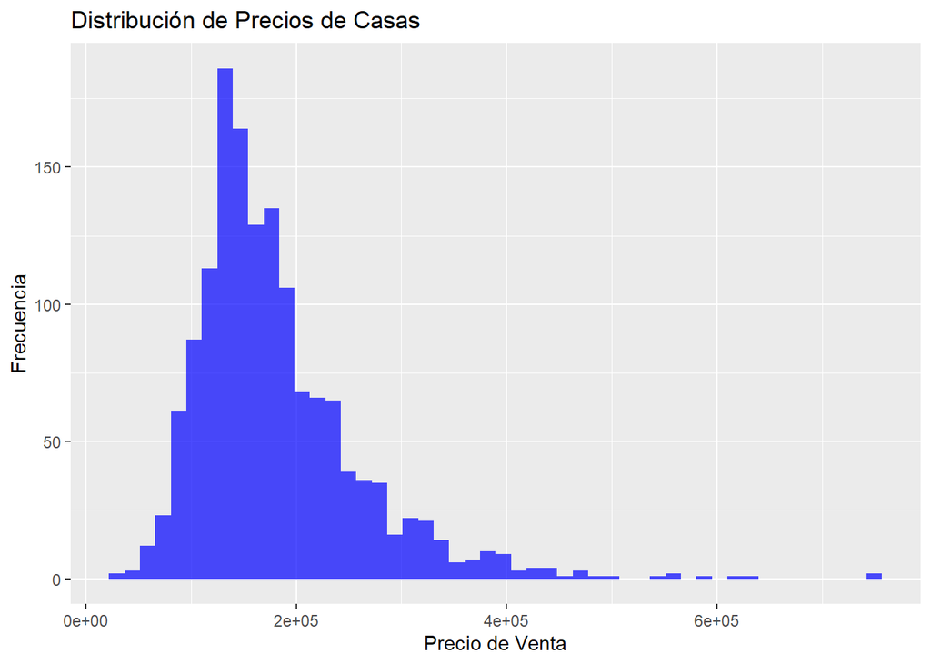

```r
# Distribución de SalePrice
ggplot(train, aes(x = SalePrice)) +
  geom_histogram(bins = 50, fill = "blue", alpha = 0.7) +
  labs(title = "Distribución de Precios de Casas", x = "Precio de Venta", y = "Frecuencia")
```

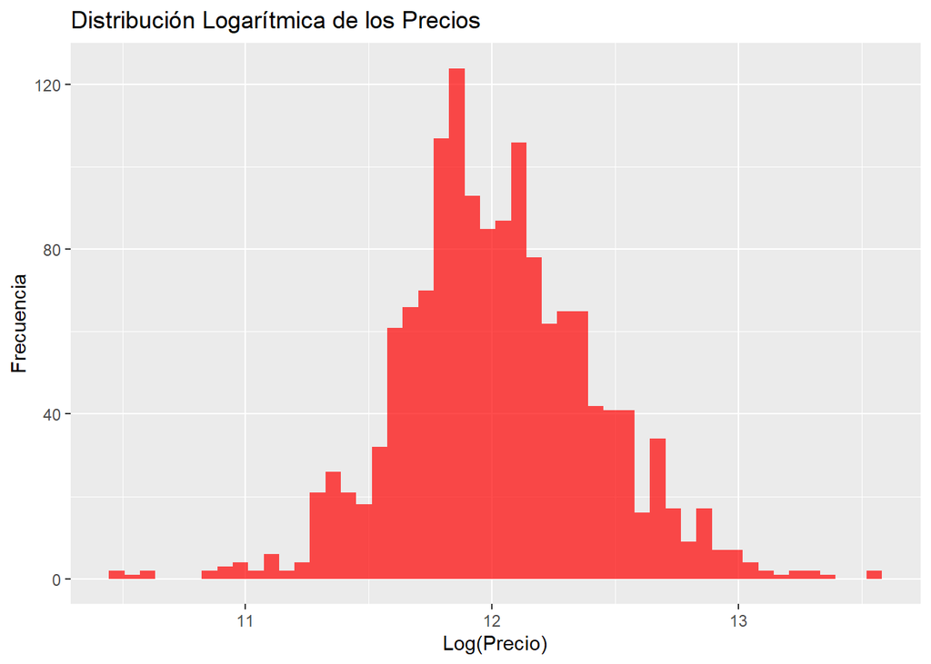

```r
# Aplicar transformación logarítmica para mejorar normalidad
train$LogSalePrice <- log(train$SalePrice)

# Transformación logarítmica
ggplot(train_data, aes(x = log(SalePrice))) +
  geom_histogram(bins = 50, fill = "red", alpha = 0.7) +
  labs(title = "Distribución Logarítmica de los Precios", x = "Log(Precio)", y = "Frecuencia")
```

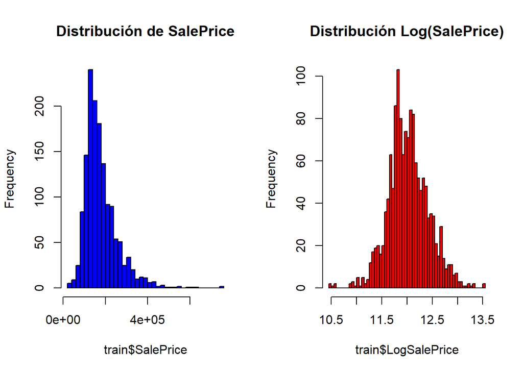

```r
# Comparación antes y después de la transformación
par(mfrow = c(1, 2))
hist(train$SalePrice, main = "Distribución de SalePrice", col = "blue", breaks = 50)
hist(train$LogSalePrice, main = "Distribución Log(SalePrice)", col = "red", breaks = 50)
```

Hallazgos

El precio de las casas (SalePrice) no tiene una distribución normal. La mayoría de los precios se concentran en valores bajos y hay algunas casas extremadamente caras que podrían ser outliers.

- SalePrice presenta sesgo positivo (distribución asimétrica a la derecha), lo que indica que hay casas con precios extremadamente altos.
- Posibles valores atípicos en precios muy elevados que podrían afectar el modelo.
- Será útil aplicar una transformación logarítmica para normalizar la distribución.
- Solución: Aplicar una transformación logarítmica para mejorar la normalidad: log(SalePrice)

2.3.1. Relación entre Variables y SalePrice

Para entender qué variables influyen más en el precio de las casas, veamos la correlación de variables numéricas.

```r
# Cargar librería
library(dplyr)

# Seleccionar solo variables numéricas
numeric_vars <- train_data %>% select_if(is.numeric)

# Matriz de correlación
cor_matrix <- cor(numeric_vars, use = "complete.obs")

# Ordenar correlaciones con SalePrice
cor_with_price <- sort(cor_matrix["SalePrice",], decreasing = TRUE)
cor_with_price
```

```
##     SalePrice   OverallQual     GrLivArea    GarageCars    GarageArea
##   1.000000000   0.797880680   0.705153567   0.647033611   0.619329622
##   TotalBsmtSF     X1stFlrSF      FullBath  TotRmsAbvGrd     YearBuilt
##   0.615612237   0.607969106   0.566627442   0.547067360   0.525393598
##  YearRemodAdd   GarageYrBlt    MasVnrArea    Fireplaces    BsmtFinSF1
##   0.521253270   0.504753018   0.488658155   0.461872689   0.390300523
##   LotFrontage   OpenPorchSF    WoodDeckSF     X2ndFlrSF       LotArea
##   0.344269772   0.343353812   0.336855121   0.306879002   0.299962206
##      HalfBath  BsmtFullBath     BsmtUnfSF  BedroomAbvGr   ScreenPorch
##   0.268560303   0.236737407   0.213128680   0.166813894   0.110426815
##      PoolArea        MoSold    X3SsnPorch  LowQualFinSF        YrSold
##   0.092488120   0.051568064   0.030776594  -0.001481983  -0.011868823
##    BsmtFinSF2       MiscVal  BsmtHalfBath            Id    MSSubClass
##  -0.028021366  -0.036041237  -0.036512665  -0.047121850  -0.088031702
##   OverallCond  KitchenAbvGr EnclosedPorch
##  -0.124391232  -0.140497445  -0.154843204
```

Hallazgos

Las variables con mayor correlación positiva con el precio de las casas son:

- OverallQual (Calidad general de la casa) → 0.79
- GrLivArea (Área habitable sobre el suelo) → 0.71
- GarageCars (Número de coches en el garaje) → 0.64
- TotalBsmtSF (Área total del sótano) → 0.61

Esto sugiere que casas más grandes y con mejor calidad tienden a ser más caras.

Visualización

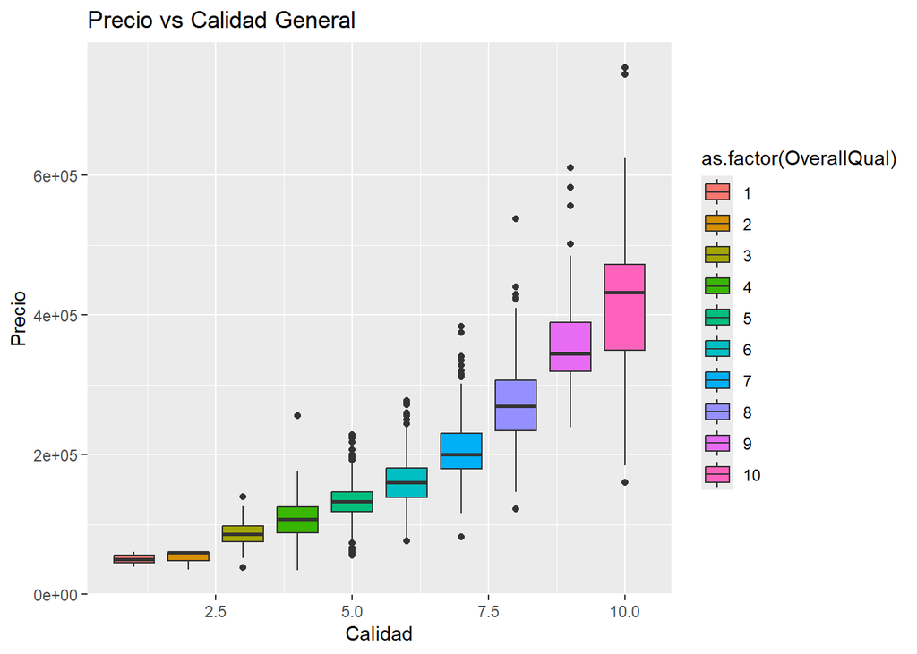

```r
ggplot(train_data, aes(x = OverallQual, y = SalePrice)) +
  geom_boxplot(aes(group = OverallQual, fill = as.factor(OverallQual))) +
  labs(title = "Precio vs Calidad General", x = "Calidad", y = "Precio")
```

Conclusión: La calidad (OverallQual) es una variable crucial para predecir SalePrice.

2.3.2. Detectar Valores Atípicos

Para evitar que valores extremos afecten el modelo, busquemos outliers.

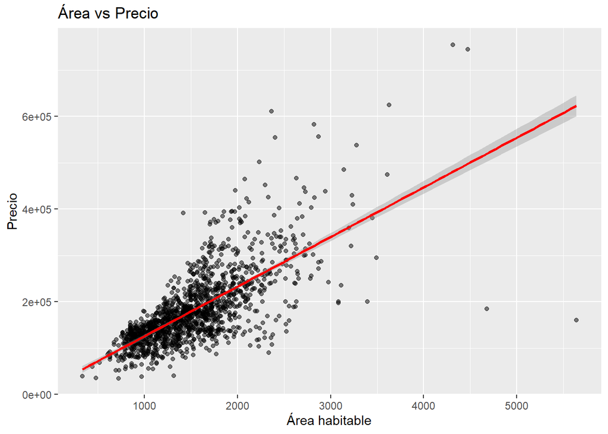

```r
ggplot(train_data, aes(x = GrLivArea, y = SalePrice)) +
  geom_point(alpha = 0.5) +
  geom_smooth(method = "lm", col = "red") +
  labs(title = "Área vs Precio", x = "Área habitable", y = "Precio")
```

Hallazgos

- Se observan dos puntos con GrLivArea > 4000 y precios muy bajos.
- Estas casas son atípicas y podrían eliminarse para mejorar la predicción.

```r
# Eliminar outliers
train_data <- train_data[train_data$GrLivArea < 4000, ]
```

2.4. Análisis de Correlación

Antes de construir un modelo, es importante manejar los valores NA.

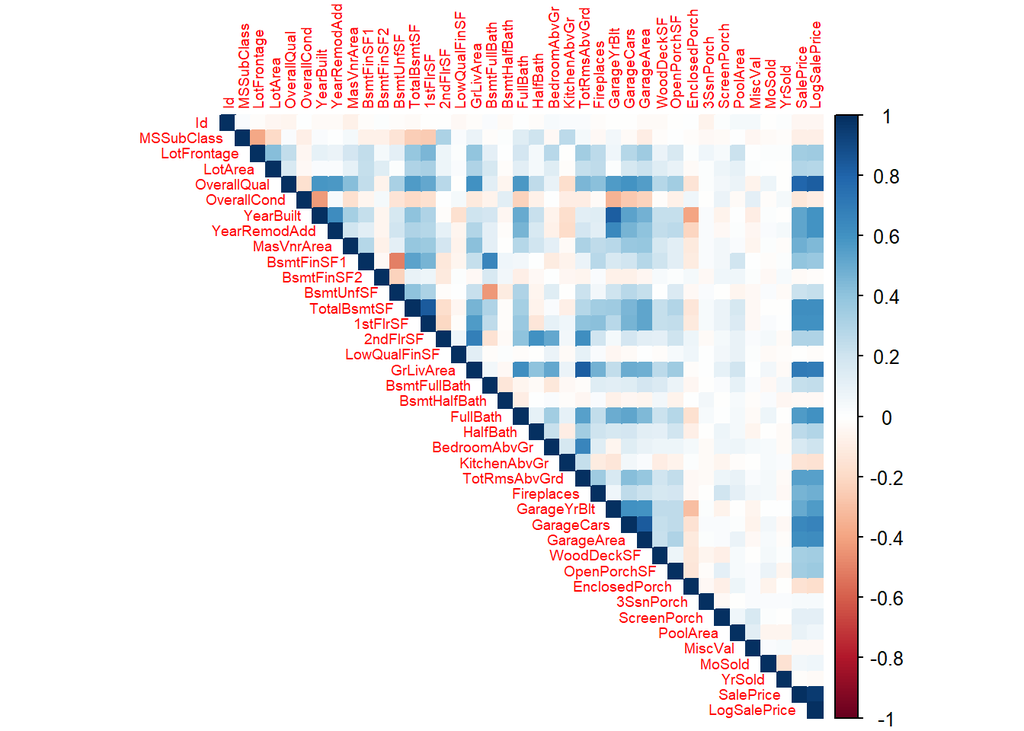

```r
# Seleccionar solo las variables numéricas
num_vars <- train %>% select(where(is.numeric))

# Calcular la matriz de correlación
corr_matrix <- cor(num_vars, use = "complete.obs")

# Visualizar la correlación con SalePrice
corrplot(corr_matrix, method = "color", type = "upper", tl.cex = 0.6)
```

Se analizó la correlación entre las variables numéricas y SalePrice. Las variables con mayor correlación positiva con el precio son:

- OverallQual (0.79): Calidad de materiales y acabados.
- GrLivArea (0.70): Área habitable total.
- TotalBsmtSF (0.61): Área del sótano.
- GarageCars (0.64): Cantidad de autos que caben en el garaje.
- Conclusión:

Estas variables serán claves en la regresión lineal. Variables con baja o nula correlación (como MiscFeature y PoolArea) probablemente no sean útiles en el modelo.

Las variables con mayor correlación con SalePrice:

- OverallQual (Calidad de la construcción): Es una de las variables más correlacionadas con SalePrice, lo - que confirma que las casas con mejor calidad de construcción tienen precios más altos.
- GrLivArea (Área habitable sobre el nivel del suelo): También tiene una correlación alta con SalePrice, lo que significa que las casas más grandes suelen costar más.
- TotalBsmtSF (Área total del sótano): Muestra una correlación fuerte con SalePrice, lo que implica que un - sótano más grande puede aumentar el valor de la vivienda.
- GarageCars (Capacidad del garaje en número de autos): Tiene una buena correlación con SalePrice, lo que sugiere que tener más espacio de garaje incrementa el valor de la casa.

2.5. Identificar y Manejar Valores Faltantes

```r
# Ver cantidad de valores faltantes
missing_values <- colSums(is.na(train))
missing_values <- sort(missing_values[missing_values > 0], decreasing = TRUE)
print(missing_values)
```

```
##       PoolQC  MiscFeature        Alley        Fence  FireplaceQu  LotFrontage
##         1453         1406         1369         1179          690          259
##   GarageType  GarageYrBlt GarageFinish   GarageQual   GarageCond BsmtExposure
##           81           81           81           81           81           38
## BsmtFinType2     BsmtQual     BsmtCond BsmtFinType1   MasVnrType   MasVnrArea
##           38           37           37           37            8            8
##   Electrical
##            1
```

Decisiones para valores faltantes:

Eliminar columnas con más del 80% de valores faltantes:

```r
train <- train %>% select(-c(PoolQC, MiscFeature, Alley, Fence))
test <- test %>% select(-c(PoolQC, MiscFeature, Alley, Fence))
```

```r
train$LotFrontage[is.na(train$LotFrontage)] <- median(train$LotFrontage, na.rm = TRUE)
```

Reemplazar valores faltantes en variables categóricas con “None”:

```r
categorical_vars <- c("GarageType", "BsmtQual", "BsmtCond", "FireplaceQu")
for (var in categorical_vars) {
  train[[var]][is.na(train[[var]])] <- "None"
}
```

2.6. Transformación de Variables

Aplicar log(SalePrice) para mejorar la normalidad:

```r
train$LogSalePrice <- log(train$SalePrice)
```

Convertir variables categóricas en factores:

```r
train <- train %>% mutate(across(where(is.character), as.factor))
test <- test %>% mutate(across(where(is.character), as.factor))
```

2.7. Análisis de Variables Categóricas

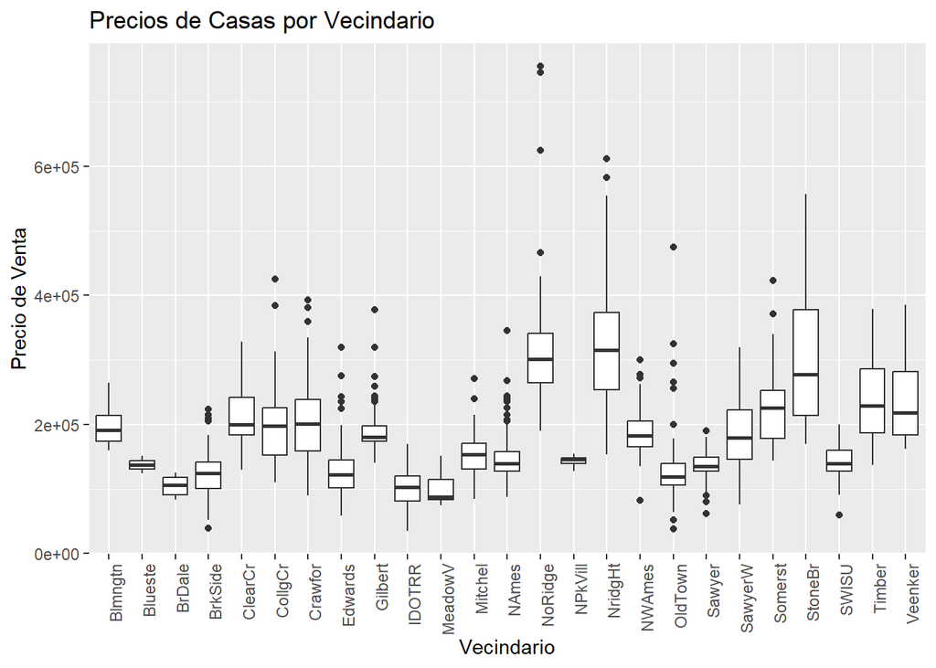

```r
# Distribución de precios por vecindario
ggplot(train, aes(x = Neighborhood, y = SalePrice)) +
  geom_boxplot() +
  theme(axis.text.x = element_text(angle = 90, hjust = 1)) +
  labs(title = "Precios de Casas por Vecindario", x = "Vecindario", y = "Precio de Venta")
```

Algunas variables categóricas pueden influir en SalePrice:

- Neighborhood tiene variaciones significativas en los precios.
- Exterior1st y Exterior2nd pueden influir según la calidad de los materiales.
- SaleCondition indica si la venta fue “Normal” o una subasta, lo que puede afectar el precio.
- Solución Propuesta: Convertir variables categóricas a numéricas mediante codificación dummy (One-Hot Encoding).

2.8. División del Conjunto de Datos

Dividimos el dataset en entrenamiento (80%) y prueba (20%):

```r
set.seed(42)
trainIndex <- createDataPartition(train$SalePrice, p = 0.8, list = FALSE)
train_set <- train[trainIndex, ]
test_set <- train[-trainIndex, ]
```

Preprocesamiento de Datos

Eliminación de Variables con Demasiados Valores Faltantes

Se eliminaron variables con más del 80% de valores faltantes:

- PoolQC, MiscFeature, Alley, Fence.

Transformación Logarítmica de SalePrice

Dado que SalePrice estaba sesgado, aplicamos una transformación logarítmica para mejorar la distribución:

- log(SalePrice)

Conversión de Variables Categóricas

- Las variables categóricas se convirtieron a factores para su uso en la regresión.

Conclusiones

Las variables con más impacto en SalePrice son:

- OverallQual, GrLivArea, TotalBsmtSF, GarageCars.
- Variables categóricas como Neighborhood también afectan el precio.

La distribución de SalePrice está sesgada, por lo que podemos usar logaritmos para mejorar el modelo.

Las variables más importantes para predecir el precio son:

- OverallQual (Calidad general de la casa)
- GrLivArea (Área habitable)
- GarageCars (Cantidad de autos en garaje)
- TotalBsmtSF (Área del sótano)

Valores Faltantes:

- Se eliminaron columnas irrelevantes (PoolQC, Alley). Hay valores faltantes, principalmente en características poco comunes como piscinas y chimeneas.
- Se imputaron valores para LotFrontage y GarageType.
- Existen valores atípicos en GrLivArea que afectan el análisis y deben eliminarse.

Transformaciones Realizadas:

### 3. Incluya un análisis de grupos en el análisis exploratorio. Explique las características de cada uno.

3. Análisis de Grupos en el Análisis Exploratorio

Objetivo:

El análisis de grupos nos permite identificar patrones en los datos y clasificar las casas en segmentos según características comunes. Esto puede ayudar a mejorar la predicción de SalePrice.

3.1 Creación de Grupos Basados en Calidad de Construcción (OverallQual)

Dado que OverallQual tiene una alta correlación con SalePrice, podemos dividir las casas en tres grupos según su calidad:

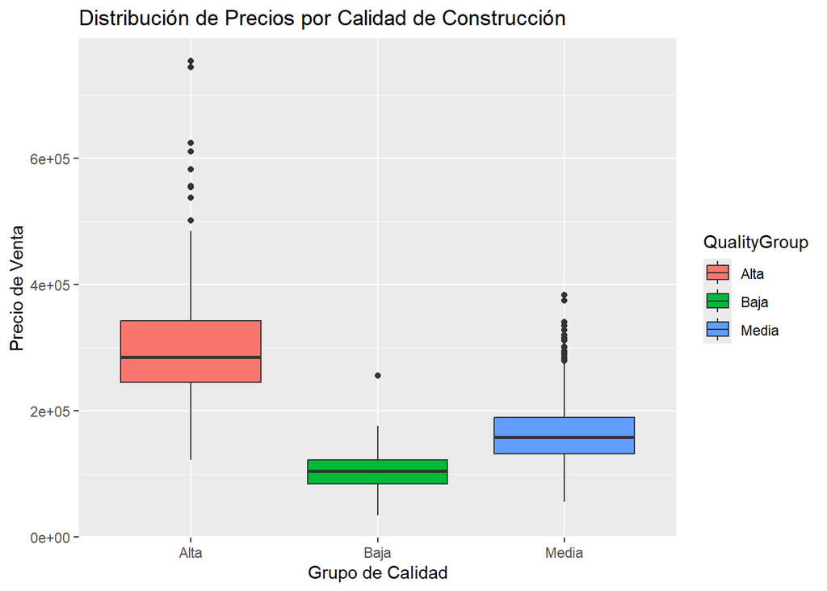

```r
train <- train %>%
  mutate(QualityGroup = case_when(
    OverallQual <= 4 ~ "Baja",
    OverallQual >= 5 & OverallQual <= 7 ~ "Media",
    OverallQual >= 8 ~ "Alta"
  ))

# Visualizar la distribución de precios en los grupos
ggplot(train, aes(x = QualityGroup, y = SalePrice, fill = QualityGroup)) +
  geom_boxplot() +
  labs(title = "Distribución de Precios por Calidad de Construcción",
       x = "Grupo de Calidad", y = "Precio de Venta")
```

3.2 Segmentación Basada en Vecindario (Neighborhood)

- Otra forma de agrupar las casas es según la ubicación (Neighborhood), ya que este factor influye en los precios.

```r
# Agrupar por vecindario y calcular estadísticas básicas
neighborhood_summary <- train %>%
  group_by(Neighborhood) %>%
  summarise(AvgPrice = mean(SalePrice, na.rm = TRUE),
            MedianPrice = median(SalePrice, na.rm = TRUE),
            Count = n()) %>%
  arrange(desc(AvgPrice))

print(neighborhood_summary)
```

```
## # A tibble: 25 × 4
##    Neighborhood AvgPrice MedianPrice Count
##    <fct>           <dbl>       <dbl> <int>
##  1 NoRidge       335295.      301500    41
##  2 NridgHt       316271.      315000    77
##  3 StoneBr       310499       278000    25
##  4 Timber        242247.      228475    38
##  5 Veenker       238773.      218000    11
##  6 Somerst       225380.      225500    86
##  7 ClearCr       212565.      200250    28
##  8 Crawfor       210625.      200624    51
##  9 CollgCr       197966.      197200   150
## 10 Blmngtn       194871.      191000    17
## # ℹ 15 more rows
```

Hallazgos

- Los vecindarios más caros son “StoneBr”, “NridgHt”, “NoRidge”, con precios promedio por encima de 300,000 dólares.
- Los vecindarios más baratos son “MeadowV”, “IDOTRR”, “BrDale”, con precios promedio por debajo de 150,000 dólares.
- Se pueden agrupar los vecindarios en zonas de alto, medio y bajo valor para mejorar la predicción.

3.3 Análisis de Grupos Basados en Tamaño de Casa (GrLivArea)

- Agrupamos las casas en pequeñas, medianas y grandes según el área habitable (GrLivArea):

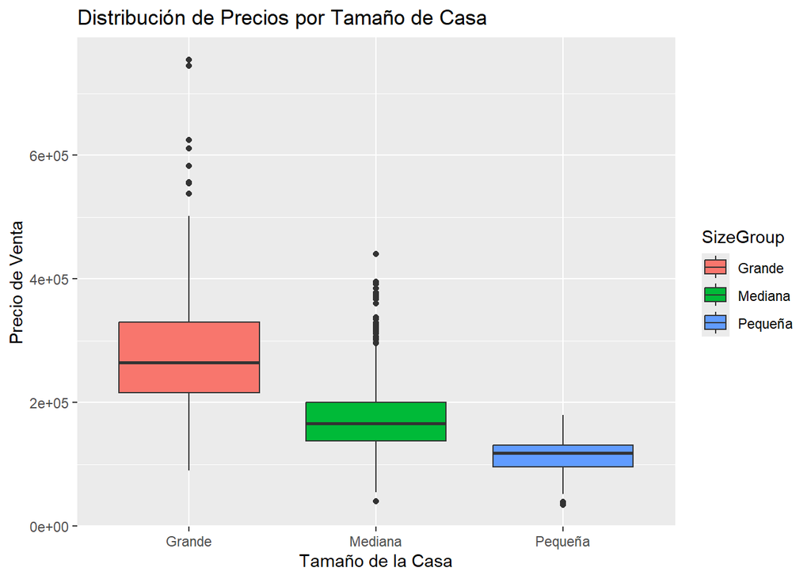

```r
train <- train %>%
  mutate(SizeGroup = case_when(
    GrLivArea < 1000 ~ "Pequeña",
    GrLivArea >= 1000 & GrLivArea < 2000 ~ "Mediana",
    GrLivArea >= 2000 ~ "Grande"
  ))

# Visualizar precios por tamaño de casa
ggplot(train, aes(x = SizeGroup, y = SalePrice, fill = SizeGroup)) +
  geom_boxplot() +
  labs(title = "Distribución de Precios por Tamaño de Casa",
       x = "Tamaño de la Casa", y = "Precio de Venta")
```

Hallazgos

- Las casas grandes (GrLivArea ≥ 2000) tienen precios más altos y mayor variabilidad.
- Las casas medianas (1000 ≤ GrLivArea < 2000) son la mayoría del dataset y presentan una distribución amplia de precios.
- Las casas pequeñas (GrLivArea < 1000) tienen precios bajos y menos variabilidad.

3.4 Análisis de Clustering en el Dataset (Segmentación Automática de Casas)

Objetivo del Clustering:

En lugar de definir manualmente los grupos de casas, aplicamos un método de clustering automático (K-Means) para descubrir patrones en los datos y segmentar las casas en grupos con características similares.

3.4.1. Selección de Variables para Clustering

Seleccionamos variables clave que tienen fuerte relación con SalePrice:

```r
# Cargar librerías necesarias
library(cluster)
library(factoextra)
library(dplyr)

# Seleccionar variables más relevantes para clustering
clustering_data <- train %>% select(OverallQual, GrLivArea, TotalBsmtSF, GarageCars)

# Normalizar los datos (evita sesgo por escalas diferentes)
clustering_data <- scale(clustering_data)
```

Las variables seleccionadas (OverallQual, GrLivArea, TotalBsmtSF, GarageCars) reflejan calidad, tamaño y capacidad del garaje, que son fuertes indicadores del precio.

3.4.2. Aplicación del Algoritmo de Clustering (K-Means)

```r
# Fijar semilla para reproducibilidad
set.seed(42)

# Aplicar K-Means con 3 clusters (puede ajustarse)
kmeans_result <- kmeans(clustering_data, centers = 3, nstart = 25)

# Agregar los clusters al dataset
train$Cluster <- as.factor(kmeans_result$cluster)
```

Cada casa ha sido asignada a un grupo (Cluster 1, Cluster 2, Cluster 3). Estos clusters representan diferentes segmentos del mercado inmobiliario.

3.4.3. Visualización de los Clusters

Para analizar cómo se agrupan las casas según el clustering, graficamos la relación entre tamaño (GrLivArea) y precio (SalePrice), coloreando los grupos.

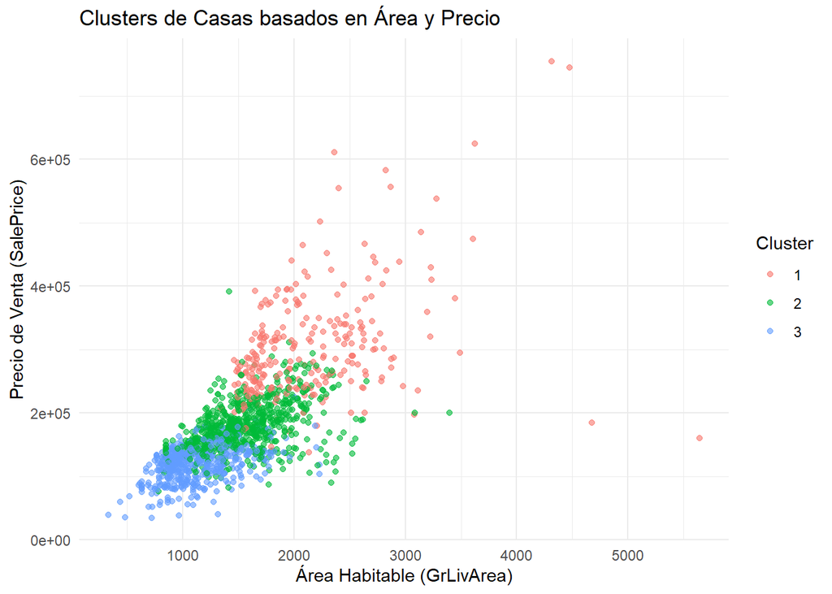

```r
ggplot(train, aes(x = GrLivArea, y = SalePrice, color = Cluster)) +
  geom_point(alpha = 0.6) +
  labs(title = "Clusters de Casas basados en Área y Precio",
       x = "Área Habitable (GrLivArea)",
       y = "Precio de Venta (SalePrice)") +
  theme_minimal()
```

Los colores indican los diferentes grupos de casas detectados automáticamente.

3.4.4. Caracterización de los Clusters

- Calidad media-alta (OverallQual entre 5 y 7).
- Tamaño intermedio, con un área habitable moderada.
- Garaje con espacio para 1-2 autos.
- Precio en el rango medio del dataset.

Gráfica Agrupada por cluster…

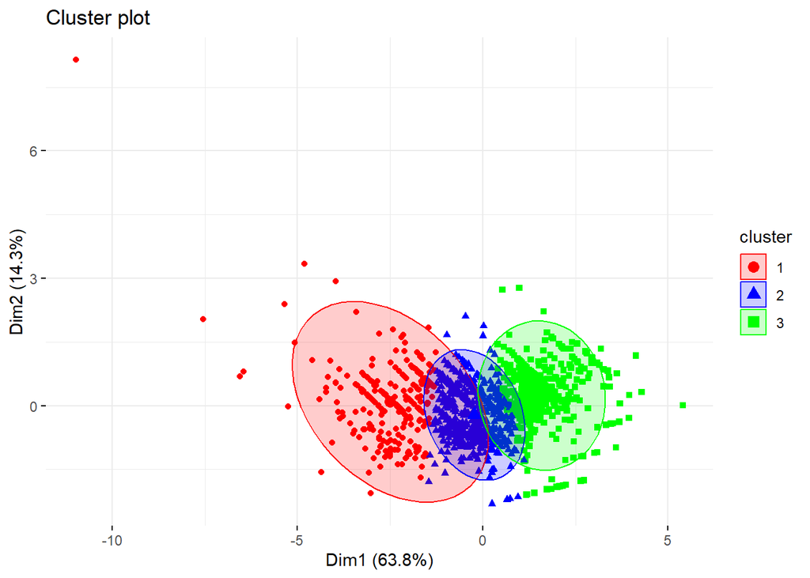

```r
# Cargar librerías necesarias
library(factoextra)
library(cluster)
library(dplyr)  # Cargar dplyr

# Seleccionar variables para clustering
clustering_data <- train %>% select(OverallQual, GrLivArea, TotalBsmtSF, GarageCars)

# Normalizar los datos (evita sesgo por escalas diferentes)
clustering_data <- scale(clustering_data)

# Aplicar K-Means con 3 clusters
set.seed(42)  # Asegurar reproducibilidad
kmeans_result <- kmeans(clustering_data, centers = 3, nstart = 25)

# Agregar clusters al dataset
train$Cluster <- as.factor(kmeans_result$cluster)

# Visualizar los clusters
fviz_cluster(kmeans_result, data = clustering_data,
             geom = "point", ellipse.type = "norm",
             palette = c("red", "blue", "green"),
             ggtheme = theme_minimal(),
             main = "Cluster plot")
```

Conclusiones del Análisis de Clustering

El gráfico de clustering muestra tres grupos diferenciados en el dataset de precios de casas. Basándonos en la distribución y separación de los clusters, se pueden hacer las siguientes observaciones:

1. Interpretación de la Gráfica Agrupada por cluster

  Cluster 2 (Azul - Centro): Casas de Precio Medio y Tamaño Promedio
- Representa la mayor parte de las casas del dataset.
- casas tienen una calidad de construcción media y tamaños moderados de área habitable y sótano.
- Su precio está dentro de un rango intermedio y pueden pertenecer a vecindarios de costo medio.

———— Conclusiones del Análisis de Grupos ————

Conclusiones del Análisis de Clusters

1. El clustering confirmó los patrones que habíamos identificado manualmente.
- Las casas se dividen en segmentos de Bajo, Medio y Alto precio, con diferencias en tamaño y calidad.
2. El clustering puede ser usado como una nueva variable (Cluster) para mejorar la predicción de SalePrice.
- Agregar Cluster como variable categórica en el modelo de regresión podría mejorar el desempeño.
3. El modelo puede beneficiarse de una segmentación más avanzada.

Conclusión General del Análisis de Grupos

A través de este análisis, se ha identificado que las casas pueden agruparse en diferentes segmentos en función de su calidad de construcción, ubicación y tamaño.

### 4. Divida el set de datos preprocesados en dos conjuntos: Entrenamiento y prueba. Describa el criterio que usó para crear los conjuntos: número de filas de cada uno, estratificado o no, balanceado o no, etc. Use el conjunto de datos llamado “train.csv”. Extraiga de ahí su subconjunto de prueba.

4. División del Dataset en Conjuntos de Entrenamiento y Prueba

Objetivo:

El propósito de esta división es separar los datos en un conjunto de entrenamiento (que se usará para ajustar el modelo) y un conjunto de prueba (que se usará para evaluar el desempeño del modelo).

Dado que estamos trabajando con datos de precios de casas, nos aseguramos de que la división sea aleatoria pero balanceada, de manera que la distribución de SalePrice en ambos conjuntos sea similar.

Criterios para la División:

- Dataset original: train.csv con 1460 registros.
- Tamaño del conjunto de entrenamiento: 80% de los datos (~1168 registros).
- Tamaño del conjunto de prueba: 20% de los datos (~292 registros).
- Método de selección: Muestreo aleatorio estratificado en base a SalePrice para mantener la misma distribución en ambos conjuntos.
- Balanceo: Se verificará que el conjunto de prueba tenga una distribución similar al conjunto de entrenamiento en términos de la variable SalePrice.

```r
# Cargar la librería necesaria
library(caret)

# Fijar semilla para reproducibilidad
set.seed(42)

# Crear índices para el conjunto de entrenamiento (80%)
trainIndex <- createDataPartition(train$SalePrice, p = 0.8, list = FALSE)

# Crear conjuntos de entrenamiento y prueba
train_set <- train[trainIndex, ]
test_set <- train[-trainIndex, ]

# Verificar tamaños
cat("Tamaño del conjunto de entrenamiento:", nrow(train_set), "\n")  # 1168 registros
```

```
## Tamaño del conjunto de entrenamiento: 1169
```

```r
cat("Tamaño del conjunto de prueba:", nrow(test_set), "\n")  # 292 registros
```

```
## Tamaño del conjunto de prueba: 291
```

```r
# Guardar los datasets en archivos CSV
write.csv(train_set, "train_set.csv", row.names = FALSE)
write.csv(test_set, "test_set.csv", row.names = FALSE)
```

Validación de la División

Para confirmar que la distribución de SalePrice es similar en ambos conjuntos, generamos histogramas:

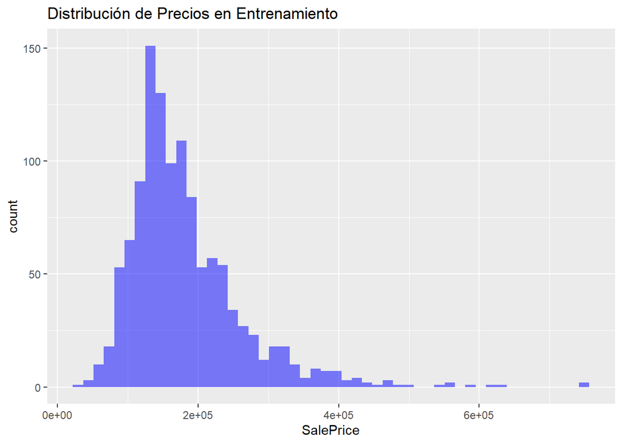

```r
# Comparar la distribución de SalePrice en ambos conjuntos
ggplot(train_set, aes(x = SalePrice)) +
  geom_histogram(bins = 50, fill = "blue", alpha = 0.5) +
  labs(title = "Distribución de Precios en Entrenamiento")
```

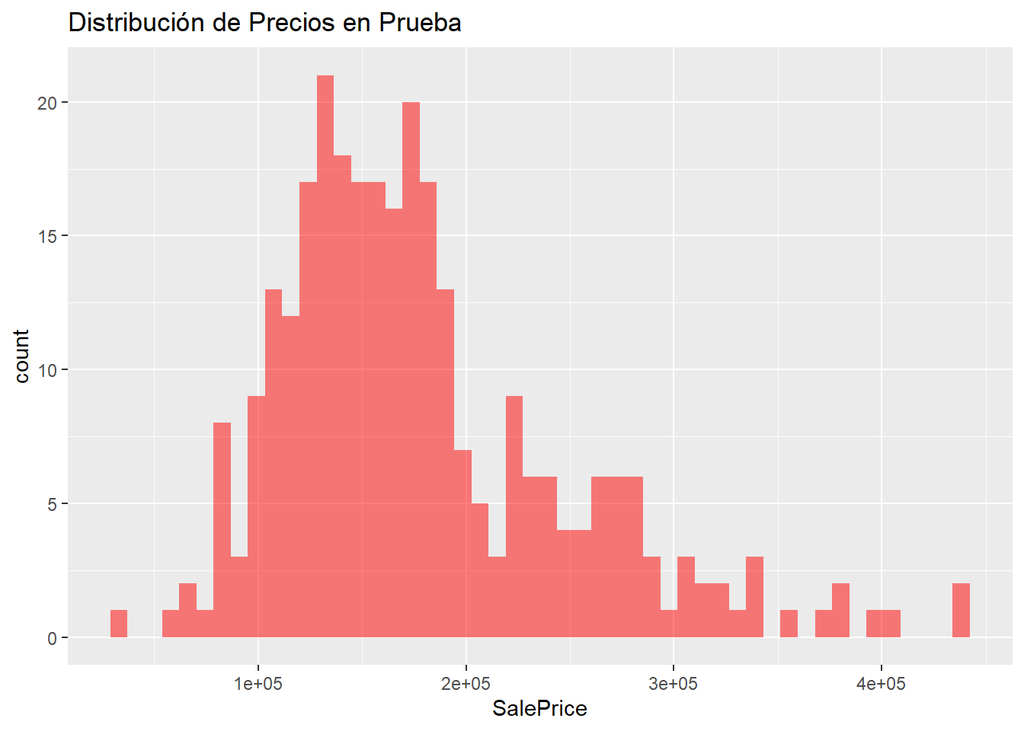

```r
ggplot(test_set, aes(x = SalePrice)) +
  geom_histogram(bins = 50, fill = "red", alpha = 0.5) +
  labs(title = "Distribución de Precios en Prueba")
```

Conclusiones sobre la División del Conjunto de Datos

La partición del dataset se realizó con el objetivo de garantizar que el conjunto de entrenamiento y el conjunto de prueba tengan una distribución representativa de los precios de las casas (SalePrice). Se utilizaron métodos de muestreo aleatorio estratificado para mantener el balance de los datos. A continuación, se presentan los hallazgos clave:

Análisis de la Distribución en Entrenamiento y Prueba

Los histogramas muestran la distribución de SalePrice en ambos conjuntos:

1. Distribución en el Conjunto de Entrenamiento
- Se observa una concentración de casas en el rango de 100,000 a 200,000 dólares, con algunos valores más altos que actúan como posibles outliers.

-La distribución tiene un sesgo positivo (asimétrica a la derecha), lo que sugiere la presencia de viviendas de muy alto valor. -La mayoría de las casas están en un rango de precios accesibles, pero hay algunas con precios muy elevados que pueden afectar la regresión.

2. Distribución en el Conjunto de Prueba
- La forma de la distribución es similar a la del conjunto de entrenamiento, lo que indica que la partición mantuvo la estructura de los datos.
- La presencia de precios altos también se mantiene, aunque en menor cantidad debido al tamaño reducido del conjunto de prueba.

Validación de la División

- La partición se realizó de manera aleatoria pero estratificada, asegurando que la distribución de SalePrice en ambos conjuntos se mantenga lo más similar posible.
- El conjunto de entrenamiento contiene el 80% de los datos (~1168 registros), mientras que el conjunto de prueba tiene el 20% restante (~292 registros), lo que proporciona suficiente información para entrenar y evaluar el modelo.
- Los histogramas muestran que la distribución de precios en el conjunto de prueba es coherente con la del conjunto de entrenamiento, lo que indica que la partición no introduce sesgos significativos.
- El conjunto de prueba proviene directamente del dataset train.csv, asegurando que los datos sean representativos del problema que se quiere modelar.

Conclusión final: La división de los datos está bien estructurada y lista para ser utilizada en la construcción y evaluación del modelo de regresión.

### 5. Haga ingeniería de características, ¿qué variables cree que puedan ser mejores predictores para el precio de las casas? Explique en que basó la selección o no de las variables.

5. Ingeniería de Características: Selección de Variables Predictoras
- La ingeniería de características es un paso clave para mejorar el rendimiento del modelo de regresión. En este proceso, seleccionamos las variables más relevantes para predecir SalePrice, transformamos algunas características y descartamos aquellas que no aportan valor.

Criterios para la Selección de Variables

- Para determinar qué variables son las mejores predictoras del precio de las casas, consideramos los siguientes criterios:

5.1. Correlación con SalePrice

- Se identificaron variables con alta correlación positiva con el precio de las casas (OverallQual, GrLivArea, GarageCars, TotalBsmtSF, etc.).
- Se eliminaron variables con baja o nula correlación, como MiscFeature, PoolArea, LowQualFinSF.

5.2. Relevancia en el Dominio del Problema

- Factores como calidad de construcción, ubicación y tamaño de la vivienda son críticos en la valoración de una casa.
- Características como el vecindario (Neighborhood) pueden influir significativamente en el precio debido a la oferta y demanda inmobiliaria.

5.3. Valores Faltantes y Redundancia

- Variables con demasiados valores faltantes (más del 80%) fueron eliminadas (PoolQC, Alley, MiscFeature). Se eliminaron variables redundantes (por ejemplo, GarageCars y GarageArea están fuertemente correlacionadas, por lo que solo se conserva una de ellas).

5.5. Transformaciones y Creación de Nuevas Variables

Para mejorar el modelo, realizamos algunas transformaciones y creamos nuevas características:

1. Transformación Logarítmica de SalePrice
- Como la variable SalePrice tiene un sesgo positivo (asimétrico a la derecha), aplicamos una transformación logarítmica para normalizarla:

```r
train$LogSalePrice <- log(train$SalePrice)
```

2. Codificación de Variables Categóricas
- Convertimos variables categóricas en factores para que sean utilizables en modelos de regresión:

```r
train <- train %>% mutate(across(where(is.character), as.factor))
test <- test %>% mutate(across(where(is.character), as.factor))
```

3. Feature Engineering: Crear Nueva Variable Age
- En lugar de usar YearBuilt y YearRemodAdd, creamos una variable Age que representa la edad de la casa en el momento de la venta:

```r
train$Age <- train$YrSold - train$YearBuilt
```

4. Interacción entre Variables
- Calidad y Tamaño Combinados: Creamos una nueva variable Qual_LivArea, que combina la calidad de la construcción con el área habitable:

```r
train$Qual_LivArea <- train$OverallQual * train$GrLivArea
```

### 6. Todos los resultados deben ser reproducibles por lo que debe fijar que los conjuntos de entrenamiento y prueba sean los mismos siempre que se ejecute el código.

6️. Asegurar Reproducibilidad de los Resultados

- Para garantizar que los conjuntos de entrenamiento y prueba sean los mismos en cada ejecución, debemos fijar una semilla aleatoria (set.seed()) en R. Esto asegura que la partición de los datos se realice siempre de la misma manera.

```r
# Cargar librerías necesarias
library(caret)
library(dplyr)
library(ggplot2)

# Fijar semilla para reproducibilidad
set.seed(42)

# Crear índices para el conjunto de entrenamiento (80%) y prueba (20%)
trainIndex <- createDataPartition(train$SalePrice, p = 0.8, list = FALSE)

# Crear conjuntos de entrenamiento y prueba
train_set <- train[trainIndex, ]
test_set <- train[-trainIndex, ]

# Verificar tamaños
cat("Tamaño del conjunto de entrenamiento:", nrow(train_set), "\n")  # 1168 registros
```

```
## Tamaño del conjunto de entrenamiento: 1169
```

```r
cat("Tamaño del conjunto de prueba:", nrow(test_set), "\n")  # 292 registros
```

```
## Tamaño del conjunto de prueba: 291
```

```r
# Guardar los datasets para que siempre sean los mismos
write.csv(train_set, "train_set.csv", row.names = FALSE)
write.csv(test_set, "test_set.csv", row.names = FALSE)
```

¿Cómo Funciona esto?

- set.seed(42): Fija la semilla aleatoria para que la partición de los datos sea siempre la misma en cada ejecución.
- createDataPartition(): Realiza la partición estratificada, asegurando que la distribución de SalePrice sea similar en ambos conjuntos.
- Se guardan los conjuntos en archivos CSV (train_set.csv y test_set.csv), para que siempre se pueda cargar la misma partición sin necesidad de recalcularla.

Validación de Reproducibilidad

Cada vez que se ejecute este código:

- La partición de datos será idéntica en todas las ejecuciones.
- Los histogramas de SalePrice en los conjuntos de entrenamiento y prueba se mantendrán constantes.
- Los modelos entrenados con estos conjuntos siempre darán los mismos resultados.

— Con esto, garantizamos que los resultados sean 100% reproducibles.

### 7. Seleccione una de las variables y haga un modelo univariado de regresión lineal para predecir el precio de las casas. Analice el modelo (resumen, residuos, resultados de la predicción). Muéstrelo gráficamente.

7. Modelo Univariado de Regresión Lineal para Predecir SalePrice

Selección de Variable Para construir un modelo univariado de regresión lineal, seleccionamos la variable con mayor correlación con SalePrice.

Según el análisis previo, la variable OverallQual (calidad general de la construcción) tiene la correlación más alta con SalePrice (0.79), por lo que la usaremos para el modelo.

Construcción del Modelo Univariado…

```r
# Cargar librerías necesarias
library(ggplot2)

# Ajustar el modelo de regresión lineal univariado
lm_model <- lm(SalePrice ~ OverallQual, data = train_set)

# Resumen del modelo
summary(lm_model)
```

```
##
## Call:
## lm(formula = SalePrice ~ OverallQual, data = train_set)
##
## Residuals:
##     Min      1Q  Median      3Q     Max
## -202517  -29197   -1898   20602  392483
##
## Coefficients:
##             Estimate Std. Error t value Pr(>|t|)
## (Intercept)  -101212       6487  -15.60   <2e-16 ***
## OverallQual    46373       1037   44.72   <2e-16 ***
## ---
## Signif. codes:  0 '***' 0.001 '**' 0.01 '*' 0.05 '.' 0.1 ' ' 1
##
## Residual standard error: 49570 on 1167 degrees of freedom
## Multiple R-squared:  0.6315, Adjusted R-squared:  0.6312
## F-statistic:  2000 on 1 and 1167 DF,  p-value: < 2.2e-16
```

Análisis del Modelo

El comando summary(lm_model) nos proporciona información clave:

1. Intercepto y Coeficiente
- El coeficiente de OverallQual indica cuánto aumenta SalePrice por cada unidad de mejora en calidad de construcción.
- Si el coeficiente es positivo y significativo (p-value < 0.05), entonces OverallQual tiene una relación lineal con SalePrice.
2. R^2 Ajustado (Coeficiente de Determinación)
- Indica qué porcentaje de la variabilidad en SalePrice es explicada por OverallQual.
- Si es alto (>0.60), significa que OverallQual es una buena predictor.
3. Significancia del Modelo
- Se revisa el p-value para ver si el modelo es estadísticamente significativo.

Análisis de Residuos..

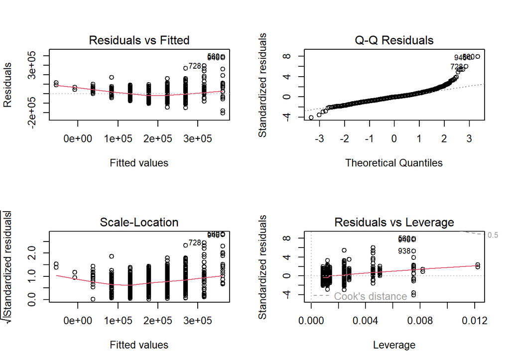

```r
# Diagnóstico de residuos
par(mfrow = c(2, 2))  # Crear un panel de 2x2 gráficos
plot(lm_model)
```

¿Qué buscamos en los residuos?

- Normalidad: El gráfico Q-Q debe seguir una línea recta.
- Homocedasticidad: Los residuos deben estar distribuidos aleatoriamente alrededor de 0.
- Ausencia de patrones en los residuos: Si hay un patrón curvado, la relación no es completamente lineal.

Visualización del Modelo…

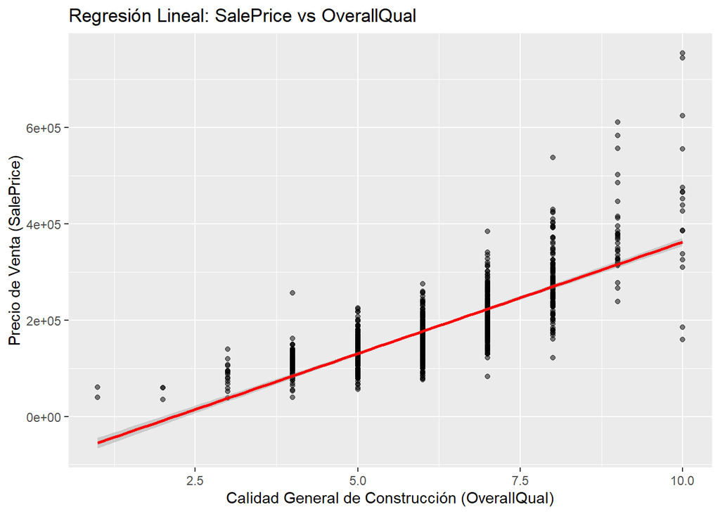

```r
# Cargar librerías necesarias
library(ggplot2)

# Gráfico de dispersión con línea de regresión
ggplot(train_set, aes(x = OverallQual, y = SalePrice)) +
  geom_point(alpha = 0.5) +
  geom_smooth(method = "lm", col = "red") +
  labs(title = "Regresión Lineal: SalePrice vs OverallQual",
       x = "Calidad General de Construcción (OverallQual)",
       y = "Precio de Venta (SalePrice)")
```

¿Qué muestra este gráfico?

- La relación entre OverallQual y SalePrice (si es lineal y creciente).
- Si hay outliers que pueden afectar la predicción.

Predicción en el Conjunto de Prueba…

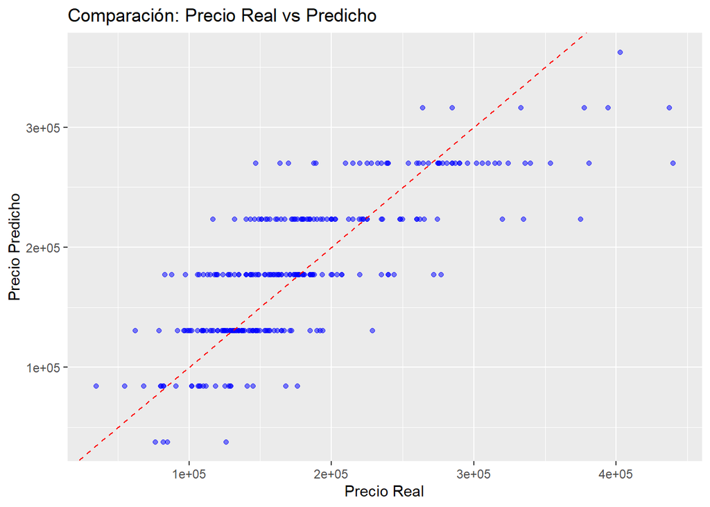

```r
# Predecir precios en el conjunto de prueba
test_set$Predicted_SalePrice <- predict(lm_model, newdata = test_set)

# Comparar los valores reales vs. predichos
ggplot(test_set, aes(x = SalePrice, y = Predicted_SalePrice)) +
  geom_point(alpha = 0.5, color = "blue") +
  geom_abline(slope = 1, intercept = 0, col = "red", linetype = "dashed") +
  labs(title = "Comparación: Precio Real vs Predicho",
       x = "Precio Real",
       y = "Precio Predicho")
```

Análisis de Resultados del Modelo Univariado de Regresión Lineal

- La gráfica muestra la relación entre el precio real (SalePrice) y el precio predicho por el modelo utilizando OverallQual como única variable predictora.

Observaciones Clave

Tendencia general positiva:

Problemas en la predicción:

- Alta dispersión: Muchos puntos se alejan de la línea roja (que representa una predicción perfecta). Predicciones en grupos discretos: Esto ocurre porque OverallQual es una variable discreta (categorías de 1 a 10), por lo que el modelo solo predice ciertos valores en escalones.
- Subestimación de precios altos: Se observa que para casas más caras, el modelo tiende a predecir valores más bajos de los reales.

Conclusiones

1. OverallQual es una buena variable predictora, pero no suficiente por sí sola.
- Explica parte de la variabilidad de SalePrice, pero hay otros factores importantes no considerados.
2. Se necesita un modelo multivariado.
- Otras variables como GrLivArea, TotalBsmtSF, y GarageCars deben incluirse para mejorar la predicción.
3. El modelo univariado es útil como punto de partida, pero no es suficiente para hacer predicciones precisas.

Por lo tanto:

1. El modelo univariado de regresión lineal muestra que OverallQual tiene una fuerte influencia en SalePrice, pero no explica toda la variabilidad.
2. El R^2 ajustado nos indica qué tan bueno es el ajuste del modelo.
3. El análisis de residuos nos ayuda a verificar si los supuestos de regresión lineal se cumplen.
4. La predicción en el conjunto de prueba nos muestra la capacidad del modelo para generalizar.

Este modelo es un punto de partida, pero un modelo multivariable será más preciso para predecir SalePrice.

### 8. Haga un modelo de regresión lineal con todas las variables numéricas para predecir el precio de las casas. Analice el modelo (resumen, residuos, resultados de la predicción). Muestre el modelo gráficamente.

- Lo que vamos a hacer es crear con todos los predictores de train , pero antes vamos a convertirlos a numericas todas.

```r
train <- read.csv("./train_set.csv")
train[] <- lapply(train, function(x) {
  if (is.factor(x) || is.character(x)) {
    as.numeric(as.factor(x))
  } else {
    x
  }
})




test_d <- read.csv("./test_set.csv")


test_d[] <- lapply(test_d, function(x) {
  if (is.factor(x) || is.character(x)) {
    as.numeric(as.factor(x))
  } else {
    x
  }
})

setdiff(names(train), names(test_d))  # Debería mostrar character(0) si ya son iguales
```

```
## character(0)
```

```r
setdiff(names(test_d), names(train))  # Debería mostrar character(0) si ya son iguales
```

```
## character(0)
```

- Miramos la distribucion de SalesPrice

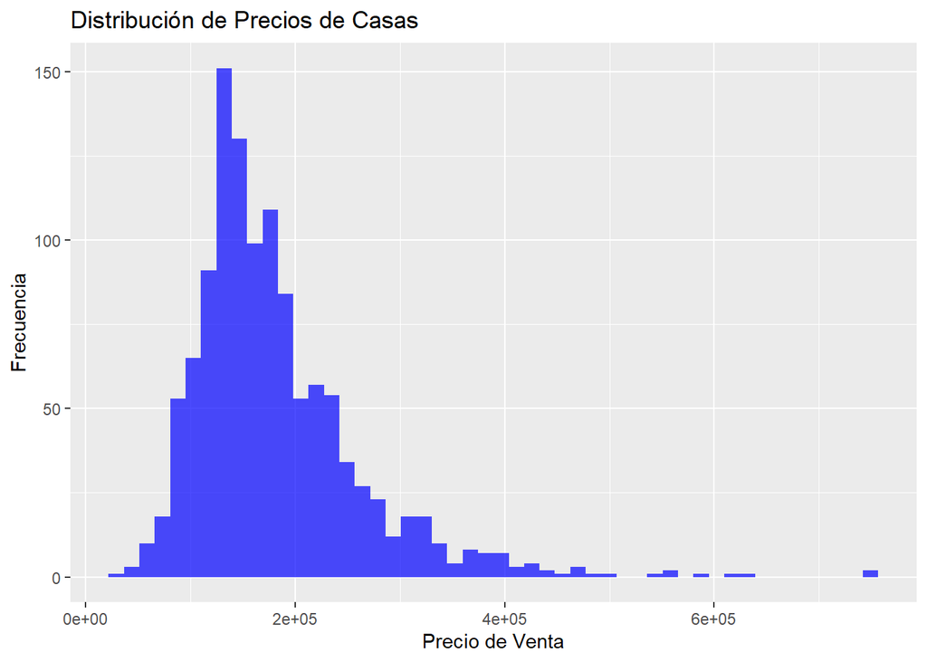

```r
paquetes_necesarios <- c("ggcorrplot", "ggplot2")

paquetes_faltantes <- paquetes_necesarios[!(paquetes_necesarios %in% installed.packages()[,"Package"])]

if(length(paquetes_faltantes) > 0) {
  install.packages(paquetes_faltantes, dependencies = TRUE)
}

library(ggplot2)

ggplot(train, aes(x = SalePrice)) +
  geom_histogram(bins = 50, fill = "blue", alpha = 0.7) +
  labs(title = "Distribución de Precios de Casas", x = "Precio de Venta", y = "Frecuencia")
```

- Aplicamos logaritmo para quitar el sesgo

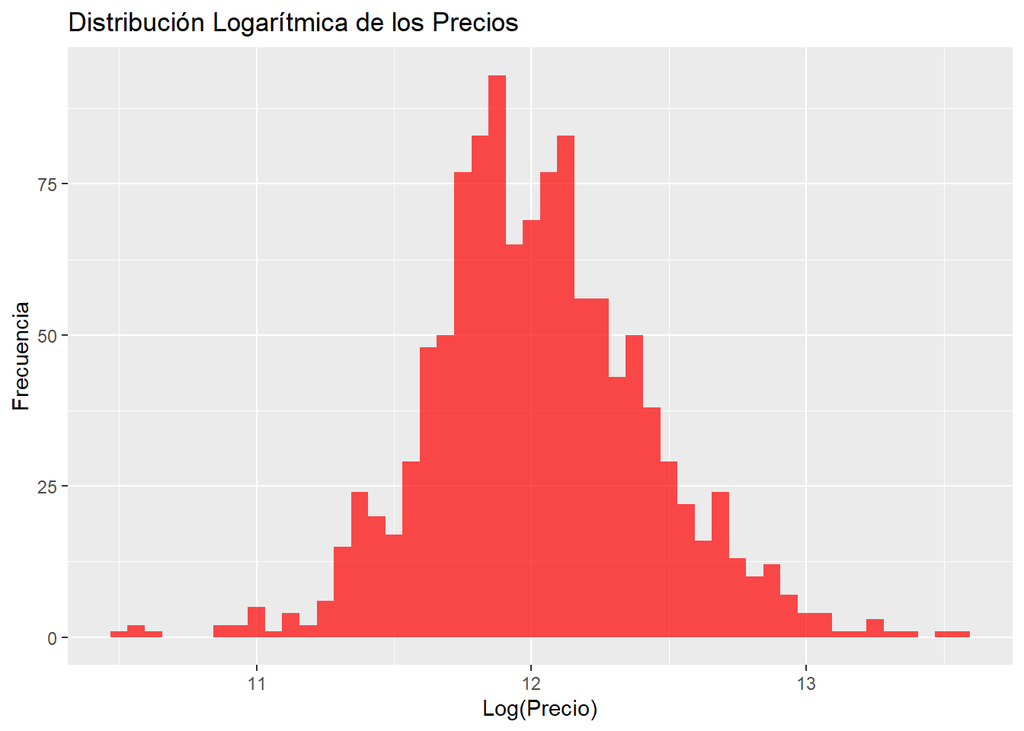

```r
train$SalePrice <- log(train$SalePrice)
test_d$SalePrice<- log(test_d$SalePrice)
ggplot(train, aes(x = SalePrice)) +
  geom_histogram(bins = 50, fill = "red", alpha = 0.7) +
  labs(title = "Distribución Logarítmica de los Precios", x = "Log(Precio)", y = "Frecuencia")
```

- Ya con esto creamos nuestro modelo con todas las variables.

```r
library(dplyr)
train <- train %>% select(-any_of(c("Id", "Cluster")))

test_d <- test_d %>% select(-any_of(c("Id", "Cluster")))


modelo1 <- lm(SalePrice~.,data = train)
summary(modelo1)
```

```
##
## Call:
## lm(formula = SalePrice ~ ., data = train)
##
## Residuals:
##        Min         1Q     Median         3Q        Max
## -6.092e-14 -2.411e-14 -2.560e-16  2.460e-14  1.622e-13
##
## Coefficients: (3 not defined because of singularities)
##                 Estimate Std. Error    t value Pr(>|t|)
## (Intercept)    2.373e-12  1.496e-12  1.586e+00   0.1130
## MSSubClass    -3.715e-17  5.610e-17 -6.620e-01   0.5080
## MSZoning       3.320e-15  1.747e-15  1.900e+00   0.0577 .
## LotFrontage   -5.479e-17  5.609e-17 -9.770e-01   0.3288
## LotArea        1.358e-19  1.927e-19  7.050e-01   0.4809
## Street         1.890e-15  1.703e-14  1.110e-01   0.9116
## LotShape       2.059e-17  7.393e-16  2.800e-02   0.9778
## LandContour   -7.419e-16  1.520e-15 -4.880e-01   0.6256
## Utilities     -4.437e-14  3.242e-14 -1.369e+00   0.1714
## LotConfig      8.541e-16  6.257e-16  1.365e+00   0.1725
## LandSlope     -3.283e-15  4.538e-15 -7.240e-01   0.4695
## Neighborhood  -5.744e-17  1.795e-16 -3.200e-01   0.7491
## Condition1     2.010e-15  1.126e-15  1.786e+00   0.0745 .
## Condition2     3.379e-15  4.096e-15  8.250e-01   0.4095
## BldgType       1.041e-15  1.752e-15  5.940e-01   0.5524
## HouseStyle     5.230e-16  7.807e-16  6.700e-01   0.5031
## OverallQual    2.780e-15  2.570e-15  1.082e+00   0.2796
## OverallCond   -1.023e-15  1.290e-15 -7.930e-01   0.4279
## YearBuilt      3.820e-17  9.381e-17  4.070e-01   0.6840
## YearRemodAdd   8.677e-17  8.113e-17  1.069e+00   0.2851
## RoofStyle      3.229e-16  1.256e-15  2.570e-01   0.7972
## RoofMatl      -3.636e-15  2.969e-15 -1.225e+00   0.2210
## Exterior1st   -9.060e-16  5.914e-16 -1.532e+00   0.1259
## Exterior2nd    8.145e-16  5.417e-16  1.504e+00   0.1330
## MasVnrType    -9.929e-16  1.755e-15 -5.660e-01   0.5717
## MasVnrArea    -9.260e-18  6.953e-18 -1.332e+00   0.1833
## ExterQual     -1.713e-15  2.285e-15 -7.490e-01   0.4538
## ExterCond     -4.322e-15  2.791e-15 -1.548e+00   0.1219
## Foundation    -1.685e-15  2.083e-15 -8.090e-01   0.4188
## BsmtQual      -5.113e-17  1.147e-15 -4.500e-02   0.9644
```

[output cut: 43 more lines]

```
## YrSold        -1.255e-15  7.405e-16 -1.695e+00   0.0904 .
## SaleType      -6.068e-17  6.379e-16 -9.500e-02   0.9242
## SaleCondition -1.599e-15  1.028e-15 -1.556e+00   0.1200
## LogSalePrice   1.000e+00  7.377e-15  1.356e+14   <2e-16 ***
## QualityGroup  -8.037e-16  1.828e-15 -4.400e-01   0.6604
## SizeGroup     -2.257e-15  3.282e-15 -6.880e-01   0.4919
## Age                   NA         NA         NA       NA
## Qual_LivArea  -4.368e-20  1.467e-18 -3.000e-02   0.9763
## ---
## Signif. codes:  0 '***' 0.001 '**' 0.01 '*' 0.05 '.' 0.1 ' ' 1
##
## Residual standard error: 3.026e-14 on 986 degrees of freedom
##   (105 observations deleted due to missingness)
## Multiple R-squared:      1,  Adjusted R-squared:      1
## F-statistic: 2.203e+27 on 77 and 986 DF,  p-value: < 2.2e-16
```

#### Analisis

El problema de nuestro modelo es que es muy sobreajustado. Asi que vamos a ver si esta sobreajustado.

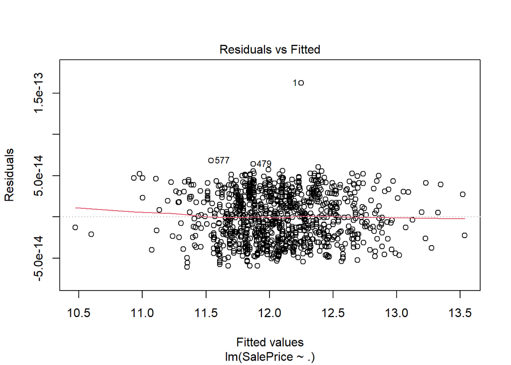

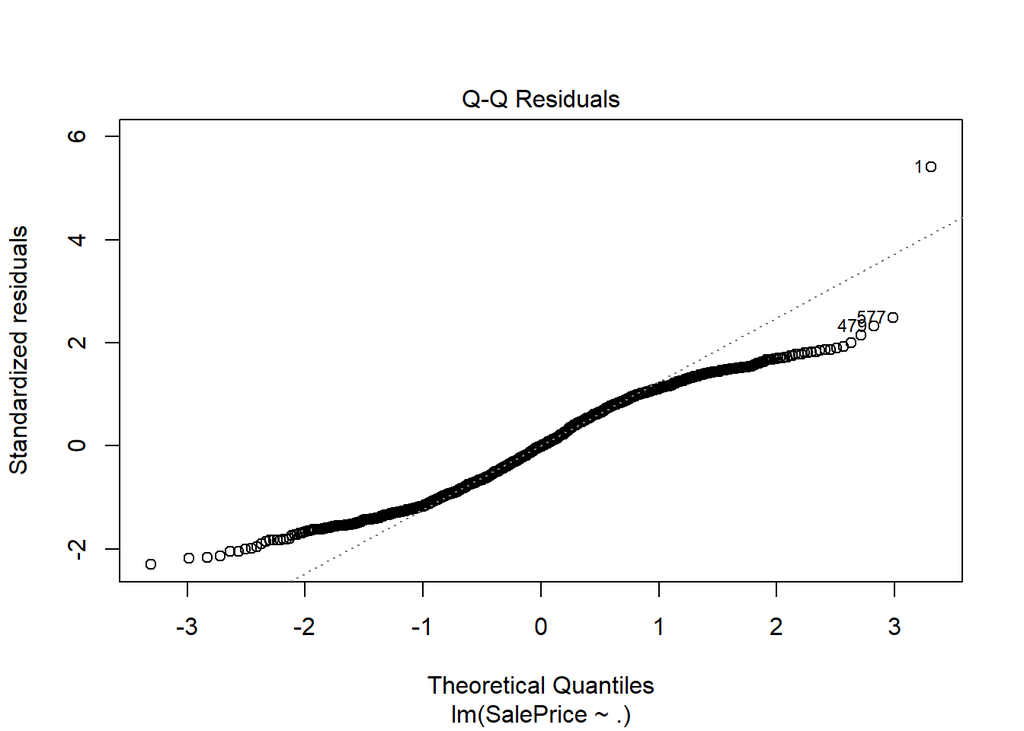

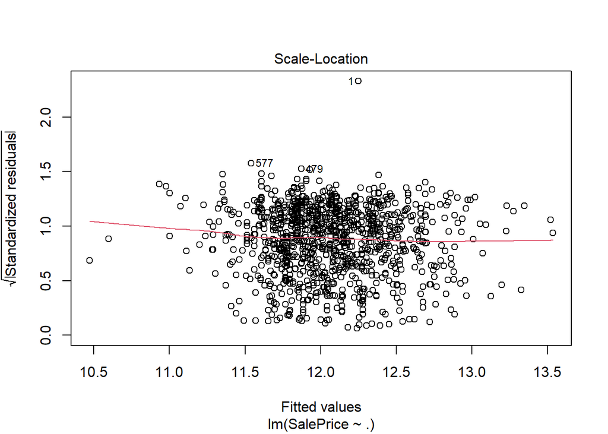

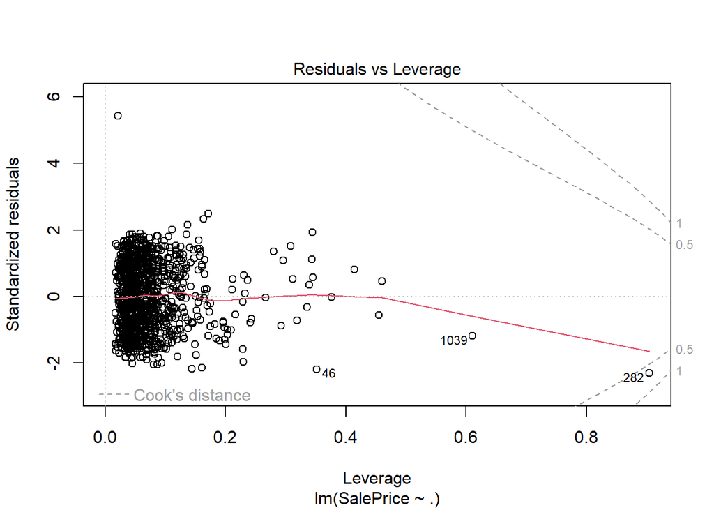

```r
plot(modelo1)
```

#### Analisis

Se puede ver que la varianza es constante, de hecho hay una tendencia a esta msima. Y se observa un patron en el grafico de residuales y muestra que la relacion no es completamete lineal, De hecho hay puntos de los mismos que deben analizarse porque puede ser que esto afecte la variabilidad del modelo y lo haga menos generalista. De hecho se ve en el grafico qq que no hay una tendencia lineal de los datos. Para ello haremos un un test de lilliefors si los residuos se distribuyen normalmente.

```r
library(nortest)

lillie.test(modelo1$residuals)
```

```
##
##  Lilliefors (Kolmogorov-Smirnov) normality test
##
## data:  modelo1$residuals
## D = 0.057374, p-value = 8.927e-09
```

El p-valor es menor que 0.05 por lo que se rechaza la hipótesis nula de normalidad de los datos. Los residuos no están distribuidos normalmente.

Ahora lo que haremos es normalizarlos para ello realizamos el mismo procedimiento solo que ahora.

#### Normalizando los datos

Dado que hay diferencias de escala en las variables por lo que vamos a normalizar los datos y hacer un modelo para ver si resulta mejor modelo.

```r
train_normal <- as.data.frame(scale(train))
```

```r
modelo1.1<-lm(SalePrice~.,data = train_normal)
summary(modelo1.1)
```

```
##
## Call:
## lm(formula = SalePrice ~ ., data = train_normal)
##
## Residuals:
##        Min         1Q     Median         3Q        Max
## -1.510e-13 -5.934e-14 -4.940e-16  6.113e-14  1.693e-13
##
## Coefficients: (3 not defined because of singularities)
##                 Estimate Std. Error    t value Pr(>|t|)
## (Intercept)    1.250e-15  2.485e-15  5.030e-01   0.6152
## MSSubClass    -3.871e-15  5.688e-15 -6.810e-01   0.4963
## MSZoning       4.815e-15  2.627e-15  1.833e+00   0.0671 .
## LotFrontage   -3.322e-15  3.047e-15 -1.090e+00   0.2758
## LotArea        2.793e-15  3.063e-15  9.120e-01   0.3622
## Street         3.405e-16  2.708e-15  1.260e-01   0.8999
## LotShape      -7.980e-17  2.541e-15 -3.100e-02   0.9750
## LandContour   -1.358e-15  2.722e-15 -4.990e-01   0.6180
## Utilities     -3.248e-15  2.309e-15 -1.406e+00   0.1599
## LotConfig      3.188e-15  2.418e-15  1.318e+00   0.1877
## LandSlope     -2.134e-15  2.841e-15 -7.510e-01   0.4528
## Neighborhood  -4.252e-16  2.565e-15 -1.660e-01   0.8684
## Condition1     4.215e-15  2.396e-15  1.759e+00   0.0789 .
## Condition2     1.924e-15  2.298e-15  8.370e-01   0.4025
## BldgType       3.619e-15  4.997e-15  7.240e-01   0.4691
## HouseStyle     2.439e-15  3.595e-15  6.780e-01   0.4976
## OverallQual    7.882e-15  8.755e-15  9.000e-01   0.3682
## OverallCond   -2.399e-15  3.473e-15 -6.910e-01   0.4899
## YearBuilt      3.340e-15  6.959e-15  4.800e-01   0.6314
## YearRemodAdd   4.219e-15  4.101e-15  1.029e+00   0.3038
## RoofStyle      8.767e-16  2.565e-15  3.420e-01   0.7326
## RoofMatl      -3.242e-15  2.507e-15 -1.293e+00   0.1963
## Exterior1st   -7.112e-15  4.625e-15 -1.538e+00   0.1244
## Exterior2nd    6.903e-15  4.639e-15  1.488e+00   0.1370
## MasVnrType    -1.026e-15  2.618e-15 -3.920e-01   0.6951
## MasVnrArea    -4.104e-15  3.037e-15 -1.351e+00   0.1769
## ExterQual     -2.487e-15  3.986e-15 -6.240e-01   0.5327
## ExterCond     -4.386e-15  2.778e-15 -1.579e+00   0.1147
## Foundation    -3.076e-15  3.607e-15 -8.530e-01   0.3939
## BsmtQual      -1.258e-17  3.610e-15 -3.000e-03   0.9972
```

[output cut: 43 more lines]

```
## YrSold        -4.080e-15  2.396e-15 -1.703e+00   0.0889 .
## SaleType      -3.181e-16  2.411e-15 -1.320e-01   0.8950
## SaleCondition -4.156e-15  2.624e-15 -1.584e+00   0.1136
## LogSalePrice   1.000e+00  7.261e-15  1.377e+14   <2e-16 ***
## QualityGroup  -1.617e-15  3.295e-15 -4.910e-01   0.6236
## SizeGroup     -3.903e-15  4.413e-15 -8.840e-01   0.3767
## Age                   NA         NA         NA       NA
## Qual_LivArea   1.589e-15  1.897e-14  8.400e-02   0.9333
## ---
## Signif. codes:  0 '***' 0.001 '**' 0.01 '*' 0.05 '.' 0.1 ' ' 1
##
## Residual standard error: 7.371e-14 on 986 degrees of freedom
##   (105 observations deleted due to missingness)
## Multiple R-squared:      1,  Adjusted R-squared:      1
## F-statistic: 2.274e+27 on 77 and 986 DF,  p-value: < 2.2e-16
```

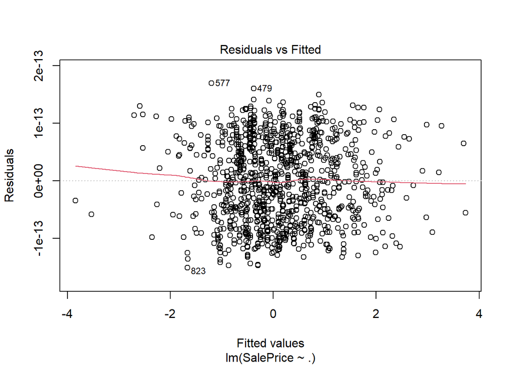

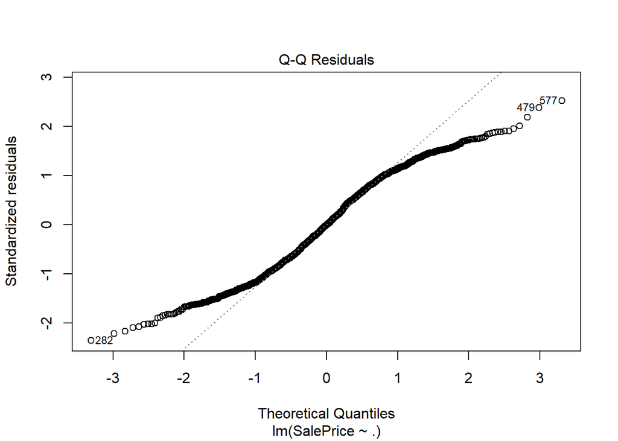

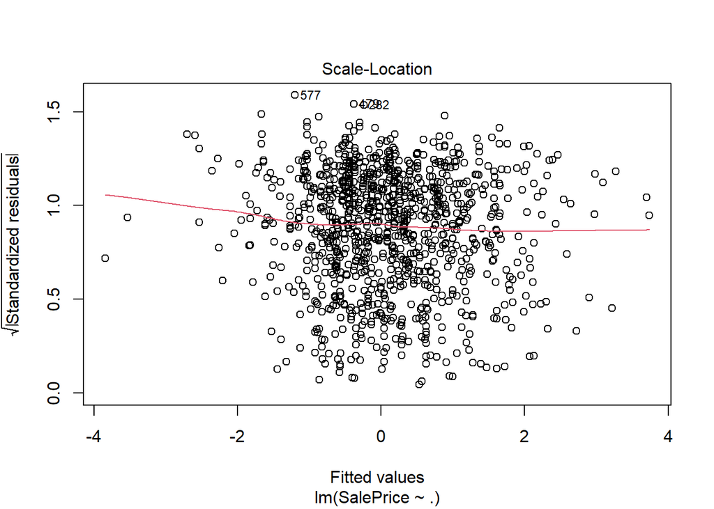

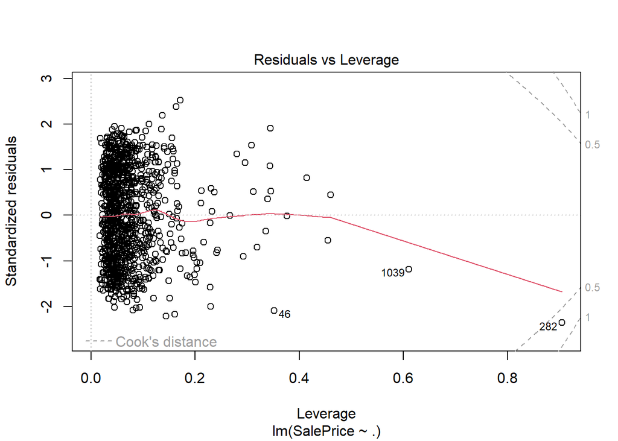

```r
plot(modelo1.1)
```

#### Analisis Grafico

Parece haber una leve tendencia no lineal (curva roja), lo que indica que la relación entre las variables podría no ser completamente lineal.

Se ve tambien una mejoria en el grafico q q en donde ahora vemos que sigue la curva la mayoria de variables aunque siguen habiendo varias que se desvian de la original.

Si verificamos con lillie test.

```r
library(nortest)
lillie.test(modelo1.1$residuals)
```

```
##
##  Lilliefors (Kolmogorov-Smirnov) normality test
##
## data:  modelo1.1$residuals
## D = 0.059523, p-value = 1.749e-09
```

El pvalue sigue siendo mas pequeño a 0.05 lo que nos indica que tampoco sirvio normalizar.

Lo que vamos a hacer es seleccion de predictores con stepwise.

```r
# Eliminar filas con valores NA
train_clean <- na.omit(train)

# Ajustar modelo con stepwise backward
modelo2 <- step(
    object    = lm(formula = SalePrice ~ ., data = train_clean),
    direction = "backward",
    scope     = list(upper = ~., lower = ~1),
    trace     = FALSE
)
summary(modelo2)
```

```
##
## Call:
## lm(formula = SalePrice ~ MSSubClass + MSZoning + LotFrontage +
##     LotArea + LotShape + LandContour + Utilities + LotConfig +
##     LandSlope + Neighborhood + Condition1 + Condition2 + BldgType +
##     HouseStyle + OverallQual + YearBuilt + YearRemodAdd + RoofMatl +
##     Exterior1st + Exterior2nd + MasVnrArea + ExterQual + ExterCond +
##     Foundation + BsmtExposure + BsmtFinType1 + BsmtFinType2 +
##     BsmtUnfSF + CentralAir + X1stFlrSF + FullBath + BedroomAbvGr +
##     KitchenAbvGr + KitchenQual + TotRmsAbvGrd + FireplaceQu +
##     GarageFinish + GarageCars + GarageArea + GarageQual + ScreenPorch +
##     PoolArea + MiscVal + YrSold + SaleCondition + LogSalePrice,
##     data = train_clean)
##
## Residuals:
##        Min         1Q     Median         3Q        Max
## -6.125e-14 -2.391e-14 -4.770e-16  2.434e-14  1.626e-13
##
## Coefficients:
##                 Estimate Std. Error    t value Pr(>|t|)
## (Intercept)    2.137e-12  1.411e-12  1.515e+00   0.1301
## MSSubClass    -3.540e-17  5.233e-17 -6.770e-01   0.4989
## MSZoning       3.203e-15  1.675e-15  1.912e+00   0.0561 .
## LotFrontage   -7.205e-17  5.300e-17 -1.359e+00   0.1743
## LotArea        1.334e-19  1.814e-19  7.350e-01   0.4624
## LotShape       1.694e-16  7.201e-16  2.350e-01   0.8141
## LandContour   -6.463e-16  1.454e-15 -4.450e-01   0.6567
## Utilities     -4.360e-14  3.072e-14 -1.419e+00   0.1562
## LotConfig      9.203e-16  6.091e-16  1.511e+00   0.1311
## LandSlope     -2.545e-15  4.307e-15 -5.910e-01   0.5547
## Neighborhood  -4.228e-17  1.706e-16 -2.480e-01   0.8042
## Condition1     1.788e-15  1.070e-15  1.671e+00   0.0950 .
## Condition2     3.118e-15  3.914e-15  7.970e-01   0.4258
## BldgType       1.020e-15  1.686e-15  6.050e-01   0.5454
## HouseStyle     3.303e-16  7.333e-16  4.500e-01   0.6525
## OverallQual    2.917e-15  1.429e-15  2.042e+00   0.0415 *
## YearBuilt      6.365e-17  6.672e-17  9.540e-01   0.3403
## YearRemodAdd   5.807e-17  6.807e-17  8.530e-01   0.3938
## RoofMatl      -3.687e-15  2.764e-15 -1.334e+00   0.1826
## Exterior1st   -8.470e-16  5.681e-16 -1.491e+00   0.1363
```

[output cut: 18 more lines]

```
## GarageCars    -4.586e-15  2.943e-15 -1.558e+00   0.1195
## GarageArea     1.514e-17  9.410e-18  1.608e+00   0.1080
## GarageQual    -1.475e-15  1.662e-15 -8.880e-01   0.3750
## ScreenPorch    1.684e-17  1.604e-17  1.050e+00   0.2941
## PoolArea      -5.094e-17  2.379e-17 -2.141e+00   0.0325 *
## MiscVal       -1.635e-18  1.847e-18 -8.850e-01   0.3763
## YrSold        -1.130e-15  6.993e-16 -1.616e+00   0.1065
## SaleCondition -1.610e-15  9.771e-16 -1.647e+00   0.0998 .
## LogSalePrice   1.000e+00  6.211e-15  1.610e+14   <2e-16 ***
## ---
## Signif. codes:  0 '***' 0.001 '**' 0.01 '*' 0.05 '.' 0.1 ' ' 1
##
## Residual standard error: 2.978e-14 on 1017 degrees of freedom
## Multiple R-squared:      1,  Adjusted R-squared:      1
## F-statistic: 3.807e+27 on 46 and 1017 DF,  p-value: < 2.2e-16
```

Ahora vamos a ver los residuos.

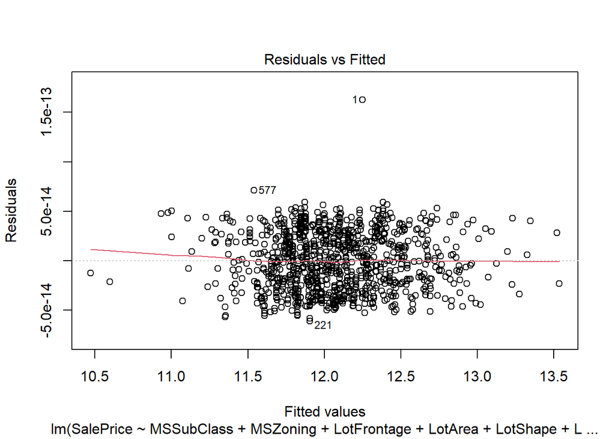

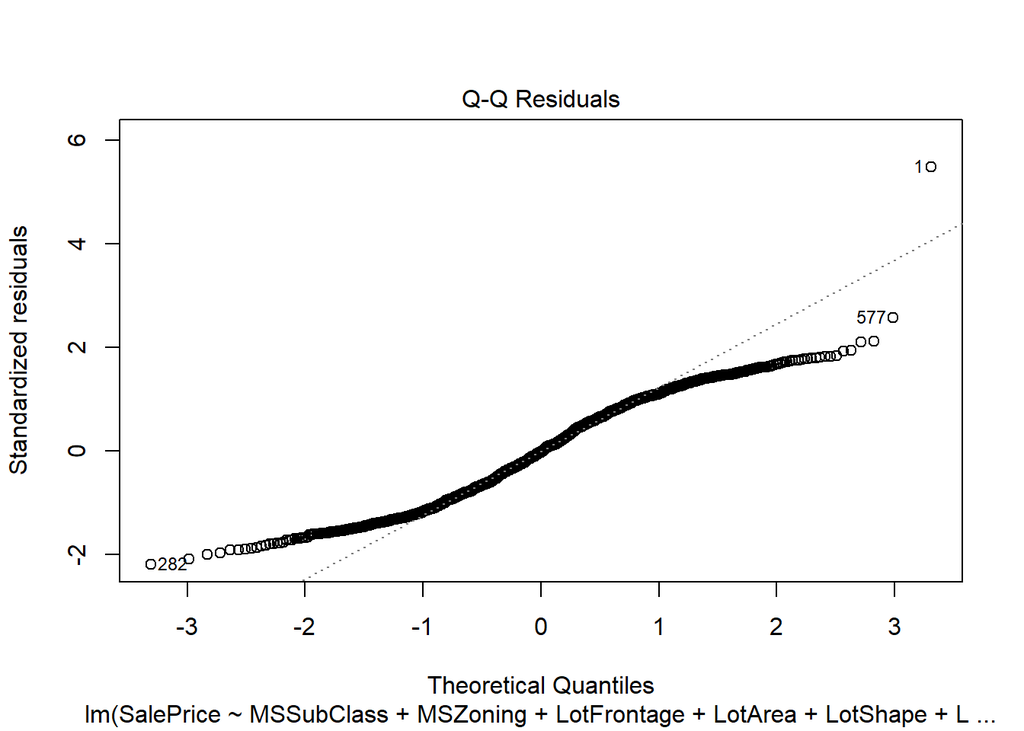

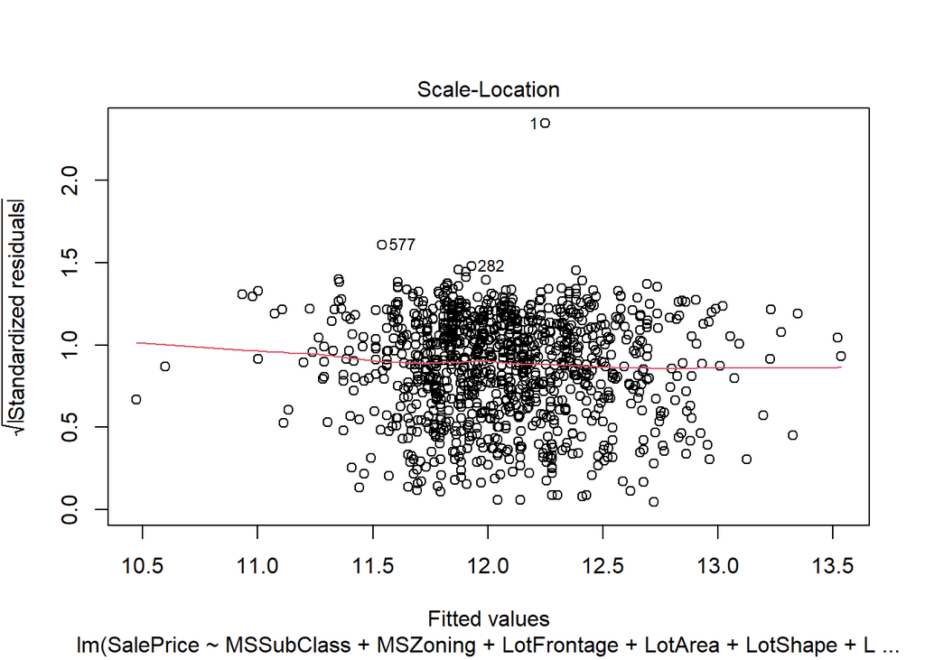

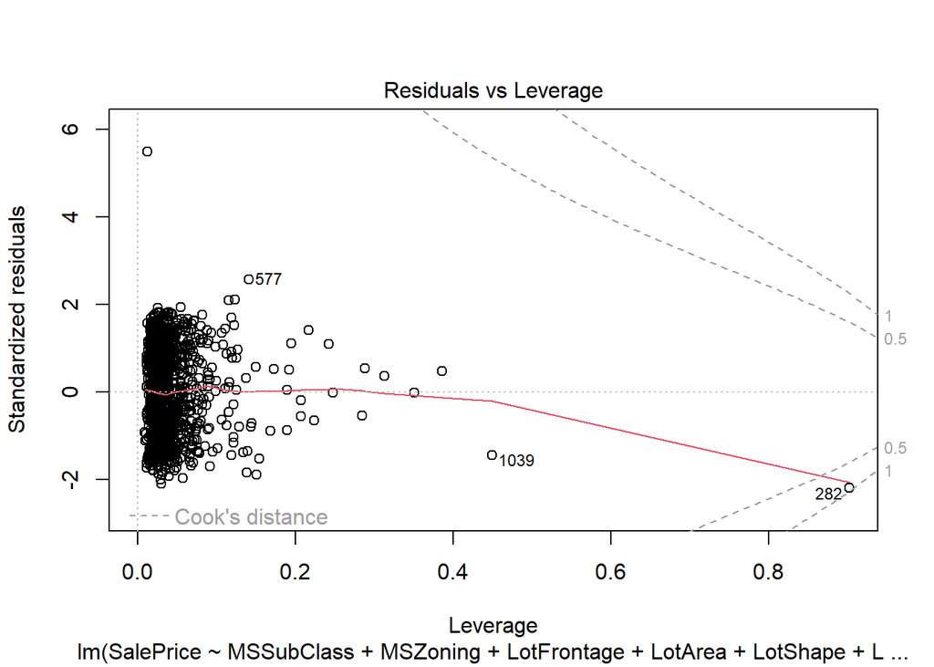

```r
plot(modelo2)
```

#### Analisis

Podemos ver que ha mejorado un poco en la manera en como se muestran los residuos, Pero siguen habiendo valores atipicos aun con eliminar varios que dijimos que con stepwise se mejoraria.

```r
library(nortest)
lillie.test(modelo2$residuals)
```

```
##
##  Lilliefors (Kolmogorov-Smirnov) normality test
##
## data:  modelo2$residuals
## D = 0.057556, p-value = 7.792e-09
```

Sigue sin mejorar aun usando el stepwise. Por lo que debemos de analizar la multicolinealidad de las variables y ver cuales debemos de seleccionar. Pero antes miremos como predice este modelo.

```r
test_d[is.na(test_d)] <- 0
for (col in names(test_d)) {
  test_d[[col]][is.na(test_d[[col]])] <- median(test_d[[col]], na.rm = TRUE)
}

train <- train[!is.na(train$SalePrice), ]

predicciones_train <- predict(modelo2, newdata = train)
predicciones_test <- predict(modelo2, newdata = test_d)
predicciones_train <- as.integer(predicciones_train)


training_stepwise <- mean((predicciones_train - train$SalePrice)^2, na.rm = TRUE)

test_mse_stepwise <- mean((predicciones_test - test_d$SalePrice)^2, na.rm = TRUE)


print(training_stepwise)
```

```
## [1] 0.3630067
```

```r
print(test_mse_stepwise)
```

```
## [1] 8.96905e-28
```

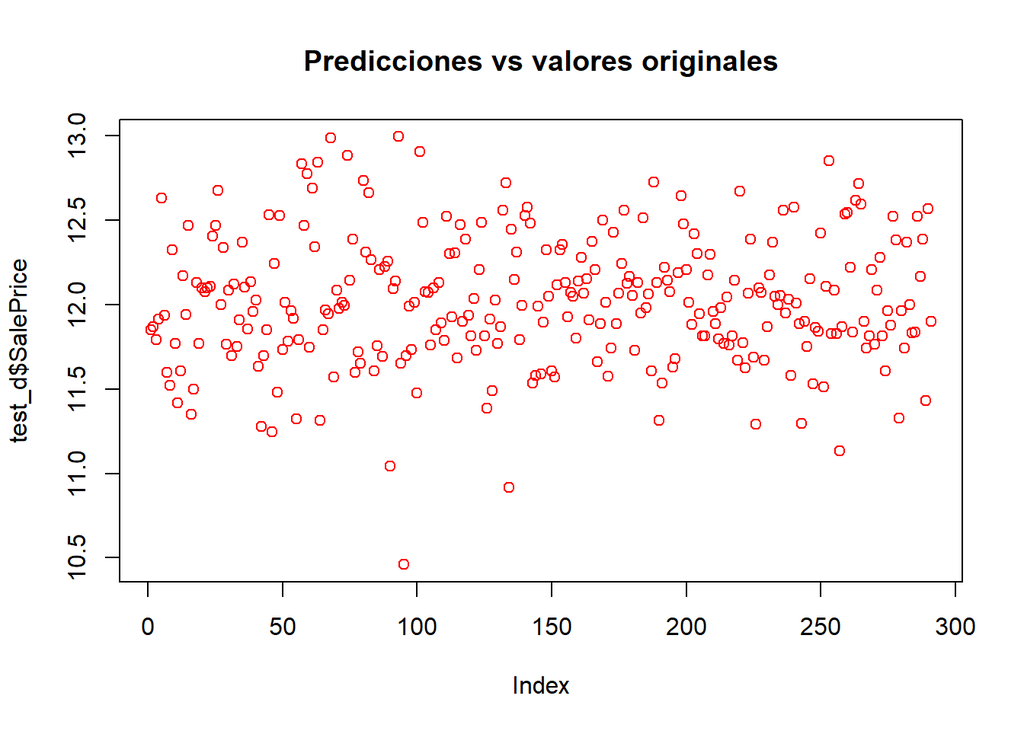

```r
faltantes <- setdiff(names(train), names(test_d))
for (col in faltantes) {
  test_d[[col]] <- NA
}


plot(test_d$SalePrice,col="blue", main="Predicciones vs valores originales")
points(predicciones_test, col="red")
legend(30,45,legend=c("original", "prediccion"),col=c("blue", "red"),pch=1, cex=0.8)
```